# Dossier RNCP 37873 — Christophe Lecart

# 00 - Présentation du Candidat

## Identité

- **Nom :** Lecart
- **Prénom :** Christophe
- **Date de naissance :** 15 décembre 1981
- **Localisation :** 76510 Notre-Dame d’Aliermont
- **Contact :** djlike@hotmail.fr | 06.70.02.80.47
- **Permis :** B / A
- **Portfolio :** https://clecart.fr

## En une phrase

Technicien industriel reconverti au développement full stack après 20 ans d’expérience terrain, je cherche une alternance pour finaliser ma transition vers le métier de Concepteur Développeur d’Applications.

## Le récit : d’où je viens, pourquoi je change

### 20 ans de terrain industriel

J’ai commencé en alternance en 2000 chez GPH comme technicien de maintenance, puis en 2002 chez Lubrizol en bureau d’études. Mon BTS MAI en poche en 2003, j’ai enchaîné chez KONE Ascenseurs (2004-2010) comme régleur et technicien de mise en service, avant de rejoindre SOCOTEC Équipements pendant 14 ans (2010-2024) en tant qu’expert en vérifications générales périodiques et mise en service.

Ces deux décennies m’ont appris :

- **Analyser des systèmes complexes** : un ascenseur, une ligne de production, un équipement de levage — comprendre comment ça marche pour diagnostiquer et corriger.
- **Travailler en autonomie sur le terrain**, avec une obligation de résultat et de sécurité.
- **Formaliser des processus** : rédiger des comptes-rendus de contrôle, des procédures de vérification, des analyses de risque.
- **Collaborer avec des ingénieurs et des opérateurs** de tous horizons, traduire les besoins métiers en spécifications techniques.
- **Travailler la rigueur** : dans le contrôle d’équipements industriels, une erreur peut coûter cher — humainement et financièrement.

### Le déclic

Le déclic n’a pas été soudain. Il s’est construit progressivement, sur plusieurs années :

- L’envie d’**outils numériques** pour automatiser les comptes-rendus, structurer les données de contrôle, faciliter le suivi des clients.
- La curiosité grandissante pour le **code** : j’ai commencé à scripter en VBA, puis Python, pour gagner du temps sur les tâches répétitives du quotidien.
- Le constat que mon **métier de technicien** atteignait un plafond de progression et que mon envie d’apprendre dépassait ce que mon poste permettait.

En 2024, j’ai pris la décision : **je passe à 100 % côté concepteur d’outils plutôt que d’utilisateur d’outils**. Pas par rejet du terrain, mais parce que je veux créer ce que j’ai utilisé pendant 20 ans.

### Zone01 Rouen Normandie — depuis 2024

J’ai rejoint **Zone01 Rouen Normandie** en 2024 pour suivre la formation de Concepteur Développeur d’Applications. La pédagogie m’a séduit :

- **Pas de cours magistraux** : on apprend par projet, en autonomie, avec un peer-coaching constant.
- **Stack moderne** : Go, JavaScript/TypeScript, React, Next.js, PostgreSQL, Docker — les technos qui se trouvent réellement sur le marché en 2025.
- **Travail en équipe** : tous les projets significatifs sont en groupe, ce qui rejoue les conditions d’une vraie équipe dev.
- **Échec encouragé** : on a le droit de se planter, c’est même attendu — l’important est de comprendre pourquoi.

Cette approche colle parfaitement à mon profil : je sais apprendre seul (20 ans à diagnostiquer des pannes m’ont entraîné), je travaille bien en équipe (j’ai toujours géré des binômes ou des juniors), et j’aime quand on me laisse trouver mon chemin plutôt qu’on me déroule un cours.

## Ce que la formation m’a apporté (au-delà des technos)

### Compétences techniques

- **TypeScript** : typage strict, génériques, inférence, schémas Zod
- **Next.js 15 + React 19** : App Router, Server Components, Server Actions
- **PostgreSQL + Prisma 6** : modélisation, migrations, queries optimisées
- **Docker + CI/CD** : conteneurisation, déploiement automatisé
- **REST + temps réel** : conception d’API, Server-Sent Events
- **Sécurité applicative** : JWT, bcrypt, OWASP Top 10, RGPD

### Compétences transverses gagnées

- **Estimation et priorisation** : découper un gros projet (Social Network) en user stories puis en sprints
- **Documentation pour pairs** : passer d’un compte-rendu industriel à une doc technique pour développeurs
- **Code review** : lire le code des coéquipiers, formuler du feedback constructif
- **Veille technique** : sélectionner les sources qui valent le temps qu’on y passe (voir 04-developpement/veille-technique.md)

### Mon évolution avant / après le projet Social Network

| Domaine | Avant le projet | Après le projet |
| --- | --- | --- |
| Architecture | Une appli = un dossier de fichiers | Architecture en couches, séparation domaine / infrastructure, choix de plateforme |
| BDD | Une table = une feuille Excel | Modélisation Merise, normalisation, contraintes d’intégrité, indexation |
| Auth | Un mot de passe en clair, ça suffit | JWT signé, bcrypt cost 12, cookies httpOnly+secure+sameSite, OAuth state cookie |
| Tests | Tests = on clique et on regarde | Pyramide de tests, tests d’intégration API, mock Prisma, jeux d’essai documentés |
| Sécurité | « C’est l’hébergeur qui s’en occupe » | OWASP Top 10, audit du code, identification des XSS résiduelles, roadmap de durcissement |
| Déploiement | Je l’envoie sur un serveur, ça doit marcher | Docker multi-stage, CI/CD, healthcheck, rollback, observabilité |

## Vision du développeur que je veux être

### Mes forces

- **Rigueur** : 20 ans de contrôle d’équipements m’ont formé à vérifier deux fois avant de valider une fois.
- **Pragmatisme** : je préfère la solution qui marche et qui se maintient à la solution élégante mais fragile.
- **Capacité d’apprentissage** : je suis autodidacte depuis toujours, le numérique n’y change rien.
- **Communication métier ↔︎ technique** : j’ai été des deux côtés du pont, je sais traduire.
- **Endurance** : un projet long ne me fait pas peur. J’ai géré des chantiers de 6 mois sur le terrain.

### Mes faiblesses (et comment je les travaille)

- **L’algorithmique pure** n’est pas mon point fort initial. Je compense par la pratique (LeetCode, exercices Zone01) et par la connaissance du contexte (un algo s’optimise dans une utilisation réelle, pas dans le vide).
- **Le réflexe « beau code »** : je dois encore me retenir de sur-architecturer. Je m’oblige à livrer en MVP puis itérer.
- **Pas de bagage informatique académique** : pas de cursus universitaire en CS. Je le compense par la curiosité (RFC, specs WHATWG, OWASP) et par les retours d’expérience pratiques.

### Ce que je ne veux pas faire

- Rester cantonné à une seule couche technique sans compréhension globale du produit.
- Développer sans tests ni validation.
- Construire des solutions difficiles à maintenir, à sécuriser, ou à passer à un collègue.
- Subir le code legacy sans le refactorer progressivement.

### Ce que je veux faire

- **Du full-stack avec une appétence backend** : conception d’API, modélisation BDD, sécurité.
- Travailler dans une **équipe où la qualité compte** : revue de code, tests, documentation.
- Contribuer à un produit qui a un **vrai usage métier** (B2B SaaS, outils internes, e-commerce, applications professionnelles).
- Progresser sur la **dimension architecture** : DDD, hexagonal, séparation domaine / infrastructure.

## Recherche d’alternance

### Format

- **Statut visé :** alternance Concepteur Développeur d’Applications (RNCP 37873).
- **Rythme :** à définir avec l’employeur (typiquement 1 semaine école / 3 semaines entreprise ou équivalent).
- **Durée :** 12 mois.
- **Démarrage :** dès obtention du titre, soit courant 2026.

### Géographie

- **Localisation principale :** Normandie (Rouen / Dieppe / Le Havre).
- **Télétravail :** ouvert au partiel ou total, équipement personnel adapté (poste fixe + portable).
- **Déplacements ponctuels :** acceptés (permis B et A, 20 ans d’habitude des déplacements professionnels).

### Profil d’entreprise cible

- **Taille :** PME, scale-up, ou département d’un grand groupe — peu importe, ce qui compte est le rythme d’apprentissage.
- **Secteur :** indifférent. Une appétence marquée pour les outils métier (B2B, industrie, contrôle qualité, gestion technique) à cause de mon expérience antérieure.
- **Stack :** ouvert. La stack du projet (TypeScript / Next.js / Prisma / PostgreSQL) me va, mais je suis volontiers preneur pour découvrir du Go, du Rust, ou d’autres écosystèmes.

### Disponibilité immédiate pour entretien

Je peux me rendre disponible à tout moment sous 48 h pour un entretien (Visio ou présentiel).

## Parcours professionnel et formation

### Parcours

- **2024 → aujourd’hui** : Zone01 Rouen Normandie — Concepteur Développeur d’Applications (RNCP 37873)
- **2010 → 2024** : SOCOTEC Équipements — Expert en vérifications générales périodiques et mise en service
- **2004 → 2010** : KONE Ascenseurs et Portes Automatiques — Technicien hautement qualifié, régleur et mise en service
- **2003 → 2004** : Missions d’intérim — Manutentionnaire, technicien, régisseur technique
- **2002 → 2003** : Lubrizol — Technicien en bureau d’études (alternance)
- **2000 → 2002** : GPH — Technicien de maintenance (alternance)

### Diplômes

- **2003** : BTS MAI (Mécanique et Automatismes Industriels)
- **2000** : BAC PRO MSMA (Maintenance des Systèmes Mécaniques Automatisés)

## Parcours

- **2024 à aujourd’hui:** Zone01 Rouen Normandie - Concepteur Développeur d’Applications (RNCP 37873)
- **2010 / 2024:** SOCOTEC Équipements - Expert en vérifications générales périodiques et mise en service
- **2004 / 2010:** KONE Ascenseurs et Portes Automatiques - Technicien hautement qualifié, régleur et mise en service
- **2003 / 2004:** Missions d’intérim diverses - Manutentionnaire, technicien, régisseur technique
- **2002 / 2003:** Lubrizol - Technicien en bureau d’études en alternance
- **2000 / 2002:** GPH - Technicien de maintenance en alternance

## Formation

- **RNCP:** 37873
- **Objectif:** obtenir une certification de niveau 6 dans un parcours orienté développement d’application
- **Diplômes antérieurs:** BTS MAI (2003), BAC PRO MSMA (2000)

## Compétences Techniques

- TypeScript, JavaScript, Java, Go
- Next.js, React, Node.js, Angular
- PostgreSQL, SQL
- Git, CI/CD, Docker, pnpm
- REST, GraphQL, chatbots IA

## Qualités Professionnelles

- Ouvert
- Curieux
- Pragmatique
- Sociable
- Proactif
- Autodidacte
- Créatif
- Rigoureux

## Centres d’Intérêt

- Musique
- Jeux vidéo
- Sport: handball et trail
- Sociologie et culture
- Astronomie

## Langues

- Français
- Anglais

# 01 - Introduction

## Contexte et Objectif

### Problématique

Le projet Social Network a pour objectif de concevoir une application web sociale moderne permettant à des utilisateurs de publier du contenu, interagir avec leur réseau, échanger en temps réel et organiser leurs échanges autour de groupes, d’événements et de notifications.

Dans le cadre de la formation Zone01 Rouen Normandie, ce projet sert de support principal pour démontrer la maîtrise d’un développement full stack structuré, sécurisé et maintenable, en environnement collaboratif.

### Solution Proposée

Plateforme de réseau social permettant:

- publication de posts, stories et médias,
- réactions et commentaires,
- messagerie privée et notifications en temps réel,
- gestion de profils, d’amis et de groupes,
- recherche et découverte de contenu.

## Informations Projet

**Titre:** Social Network  
**Type:** Application web full-stack **Repository:** arocchet/social-network **Stack Technologique:**

- Frontend: Next.js 15, React 19, TypeScript, Tailwind CSS
- Backend: Next.js API Routes, TypeScript
- Database: PostgreSQL (Neon), Prisma ORM
- Real-time: Upstash Redis, SSE/Polling
- Media: Cloudinary
- Auth: JWT (jose), bcrypt
- Deployment: Docker, Docker Compose

## Équipe et Contexte

- **Responsable:** Christophe Lecart (reconversion, 20+ ans expérience en ingénierie/conformité)
- **Cadre:** Formation Zone01 Rouen Normandie (approche pratique en équipe)
- **Projet collectif:** Développement en collaboration avec d’autres candidats
- **Date de démarrage:** 2024
- **Statut actuel:** Préparation à la certification RNCP 37873
- **Objectif post-formation:** Alternance ou CDI en développement web full-stack

### Contexte du Code Initial

Le projet a démarré avec une base fonctionnelle incomplète. Ma contribution a été d’:

- Stabiliser l’architecture (middleware, auth, API)
- Implémenter des fonctionnalités manquantes (notifications, temps réel, déploiement)
- Sécuriser l’authentification (JWT avec jose, hachage bcrypt)
- Documenter l’ensemble du système pour la certification

## Sommaire du Dossier

1. **Introduction** - Contexte et objectifs
2. **Cahier des Charges** - Spécifications fonctionnelles
3. **Conception** - Wireframes, maquettes, modélisation
4. **Développement** - Architecture et implémentation
5. **Déploiement** - Infrastructure et mise en production
6. **Bilan** - Retour d’expérience
7. **Annexes** - Code source et documentation technique

## Critères de Réussite

- Authentification sécurisée (JWT + Google OAuth, cookies HTTP-only)
- Gestion des utilisateurs (profil, avatar, bannière, visibilité)
- Création et partage de contenu (posts, stories, reels, images via Cloudinary)
- Système de réactions et de commentaires (7 types de réactions, commentaires imbriqués)
- Système de notifications en temps réel (SSE + Upstash Redis)
- Responsive design (mobile/tablet/desktop, Tailwind CSS)
- Performance optimisée (React Query, SWR, Next.js Image, code splitting)
- Tests automatisés (Jest, tests d’intégration authentification)
- Documentation complète (dossier 60+ pages, diagrammes, API spec)
- Déploiement fonctionnel (Docker multi-stage, docker-compose, Vercel)

# 02 - Cahier des Charges

## Objectifs Principaux

Le projet Social Network est réalisé en équipe dans le cadre de la formation Zone01 Rouen Normandie. Le cahier des charges ci-dessous synthétise les fonctionnalités réellement suivies dans le dépôt GitHub du projet, sous forme d’issues et de PR, puis les contraintes de mise en oeuvre qui structurent le développement.

### Organisation GitHub du projet

Le travail a été découpé en tickets GitHub pour suivre le développement en équipe. Les sujets visibles dans le dépôt couvrent notamment:

- Follow System
- Groups & Events
- Group feed — Posts & comments inside group
- Chat System
- Notifications
- DevOps: Docker, CI/CD
- CI — Lint, test, build, push image
- Seed script — Demo data
- PATCH /notifications/:id/read — Mark as read
- OAuth (Google) authentication
- Internationalization
- Settings

La stabilisation du build et du déploiement a ensuite été consolidée par la PR: [PR #118](https://github.com/arocchet/social-network/pull/118)

### Fonctionnalités Essentielles

#### Gestion des Utilisateurs

- Inscription et authentification (email/password + Google OAuth)
- Gestion de profil (avatar, bannière, bio, visibilité PUBLIC/PRIVATE)
- Système de suivi (followers/following + demandes d’amitié)

#### Publication et Interaction

- Création de posts/articles
- Commentaires et réponses
- Système de likes/réactions sur posts, stories et commentaires
- Partage de contenu
- Gestion de la visibilité des publications

#### Communication

- Système de messagerie privée
- Notifications en temps réel
- Groupes/Communautés

#### Découverte

- Recherche et filtrage (users, posts, groupes)
- Historique de recherche
- Exploration du contenu public

## Contraintes Techniques

### Sécurité

- Authentification JWT/OAuth
- Validation des données
- Chiffrement des mots de passe (bcrypt)
- Contraintes de réactions: un utilisateur ne peut pas multiplier une même réaction sur un même contenu

### Scalabilité

- Cache Redis
- Base de données PostgreSQL
- CDN pour assets

### Compatibilité

- Support navigateurs modernes (Chrome, Firefox, Safari, Edge)
- Responsive design (mobile/tablet/desktop)

### Performance

- Optimisation images (Next.js Image)
- Code splitting automatique
- Lazy loading
- Chargement fluide du feed, des profils et des conversations

## User Stories

| Utilisateur | Action | Priorité | Critères d’acceptation |
| --- | --- | --- | --- |
| Visiteur | S’inscrire |  | Email validé, compte créé |
| Utilisateur | Se connecter |  | Session JWT créée |
| Utilisateur | Créer un post |  | Post visible immédiatement |
| Utilisateur | Commenter |  | Commentaire visible |
| Utilisateur | Liker/Réagir |  | Compteur mis à jour |
| Utilisateur | Suivre un user |  | Feed personnalisé |

## Objectifs de Qualité

| Indicateur | Cible | Approche retenue |
| --- | --- | --- |
| Disponibilité | > 99 % | Docker + Vercel + Neon serverless |
| Temps de chargement | < 2 s | SSR Next.js, React Query, lazy loading |
| TTFB | < 600 ms | Edge CDN Vercel, cache Redis |
| Stabilité visuelle (CLS) | < 0.1 | Next.js Image, layout réservé |
| Couverture de tests | > 80 % | Jest, tests d’intégration API |

## Timeline

[output not shown]

Notes:

- Phase 1 (MVP - 25 jours): implémentation des fonctionnalités critiques (auth, posts, feed, basic chat, notifications).
- Phase 2 (14 jours): fonctionnalités avancées (groups, events, reels, amélioration UX, i18n).
- Phase 3 (7 jours): tests d’intégration, corrections, optimisation performances et préparation de la soutenance.

# 03 - Conception

## Documents du Projet

### Pilotage du travail

La conception s’appuie sur les issues GitHub du projet Social Network. Les lots fonctionnels ont été organisés autour des sujets suivis dans le dépôt: authentification, follow, chat, notifications, groupes, événements, settings, i18n et DevOps.

### 1⃣ Pages et Wireframes

- Accueil (Home/Feed)
- Authentification (Login/Register/Onboarding)
- Profil utilisateur
- Messages/Chat (Direct & Groupe)
- Reels/Vidéos
- Recherche
- Événements
- Groupes/Communautés
- Paramètres
- Invitations
- Design System (couleurs, typo, composants)
- Architecture page et data flow

### 3⃣ User Stories

- **38 User Stories** organisées par rôle:
  - Utilisateur classique (38 stories)
- **Priorités & Estimations:** HIGH/MEDIUM/LOW
- **Phases de développement:**
  - Phase 1 MVP (25 jours)
  - Phase 2 Features (2 semaines)
  - Phase 3 Polish (1 semaine)
- **Acceptance Criteria:** Front/Back/DevOps

### 4⃣ Diagrammes UML Complets

- **MCD** en DBML (import dbdiagram.io)
- **MLD** détaillé en DBML
- **MPD** PostgreSQL complet (DDL, contraintes, index, triggers)
- Support de présentation technique pour la soutenance

## Fonctionnalités Clés

### Réseautage Social

- Posts (texte + images + vidéos)
- Followers/Following + Amitié
- Likes/Comments/Reactions
- Stories (24h ephemeral)
- Reels (vertical short videos)

### Communication

- Direct Messages (1-to-1)
- Group Chat
- Typing Indicator + Presence
- Message Status (SENT/DELIVERED/READ)

### Groupes & Événements

- Create/Join Groups
- Group Invitations
- Events Calendar
- RSVP Management

### Discovery

- User Search
- Post Search
- Search History
- Recent Activity

### Personalization

- Theme Toggle (Light/Dark)
- Language (EN/FR)
- Notification Settings
- Privacy Controls

## Architecture de Données

### Modèles Principaux

```
User ←→ Post ←→ Comment ←→ Reaction
  │
  ├→ Friendship (2-way)
  ├→ Conversation
  │  ├→ ConversationMember
  │  ├→ GroupMessage
  │  ├→ Event
  │  │  ├→ Rsvp
  │  │  └→ GroupMessage
  │  ├→ GroupMember
  │  ├→ GroupInvitation
  │  └→ GroupJoinRequest
  │
  ├→ Story ←→ Reaction
  ├→ Message
  ├→ Notification
  ├→ UserSettings
  └→ Account (OAuth)
```

## Pages Implémentées

| Page | Route | Rôle | Statut |
| --- | --- | --- | --- |
| **Feed** | `/` | Affichage posts |  |
| **Login** | `/login` | Authentification |  |
| **Register** | `/register` | Inscription |  |
| **Onboarding** | `/onboarding` | Complétude profil |  |
| **Profil** | `/profile/[userId]` | Voir profil utilisateur |  |
| **Chat (List)** | `/chat` | Liste conversations |  |
| **Chat (Direct)** | `/chat/[id]` | Message 1-to-1 |  |
| **Reels** | `/reels` | Short videos |  |
| **Search** | `/search` | Rechercher contenu |  |
| **Groupes** | `/groups` | Lister groupes |  |
| **Groupe Detail** | `/groups/[id]` | Détail groupe + chat |  |
| **Événements** | `/events` | Calendar événements |  |
| **Paramètres** | `/settings` | Préférences user |  |
| **Invitations** | `/invitations` | Demandes d’amitié/groupe |  |

## Design System

### Palette Couleurs (Thème Dark)

**Primary Colors:**

```css
--blue40: #ff6d00 (Primary action) --blue60: #ff7900 (Hover/Active);
```

**Backgrounds:**

```css
--bgLevel1: #1a191c (Darkest) --bgLevel2: #222024 --bgLevel3: #272529
  --bgLevel4: #333036 --bgLevel5: #534e57 (Lightest);
```

**Text:**

```css
--textNeutral: #ffffff (Primary text) --textNeutralAlt: #e8e1f0 (Secondary)
  --textMinimal: #bdbdbd (Tertiary);
```

**Accents:**

```css
--red50: #a71e34 (Danger) --teal50: #56ab91 (Success) --purple60: #8b2fc9
  (Accent) --green50: #25a244 (Complete);
```

### Typography

- **Font Family:** Geist (via Next.js)
- **H1:** 28-32px
- **H2:** 20-24px
- **Body:** 14-16px
- **Small:** 12px

### Breakpoints

- Mobile: < 640px
- Tablet: 640px - 1024px
- Desktop: > 1024px

### Components

- Button, Avatar, Card, Badge, Dialog
- Input, Tabs, Switch, Notification Badge

## Data Flow

```
User Interaction
    ↓
Component State Update
    ↓
Custom Hook (useApi, usePostData, etc)
    ↓
API Request (via apiFetch)
    ↓
Backend Route Handler
    ↓
Prisma Query
    ↓
PostgreSQL
    ↓
Response
    ↓
Update Context/Provider
    ↓
Re-render Component
```

## Diagrammes

### MCD - Modèle Conceptuel de Données

Voir donnees.md - MCD Section

Représente toutes les entités et leurs relations logiques.

### MLD - Modèle Logique de Données

Voir donnees.md - MLD Section

Montre le schéma de base de données normalisé.

## Wireframes & Maquettes

### Wireframes basse-fidélité

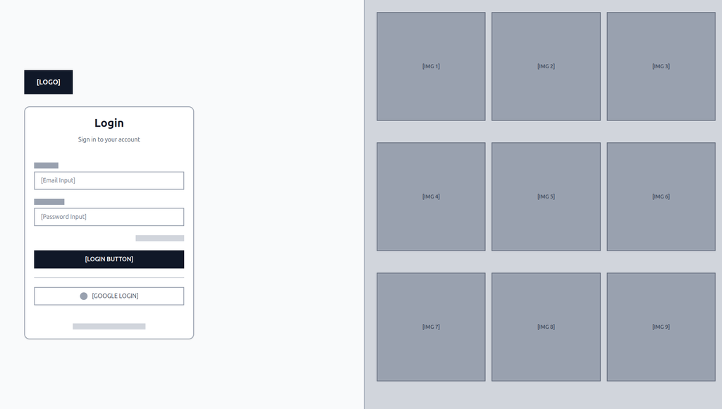

Connexion — wireframe

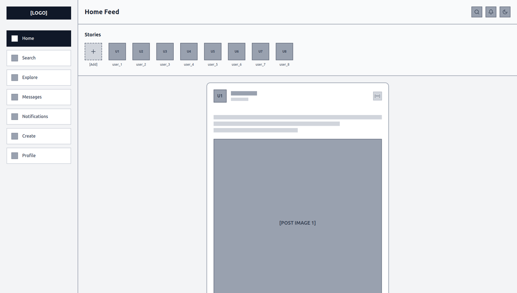

Feed principal — wireframe

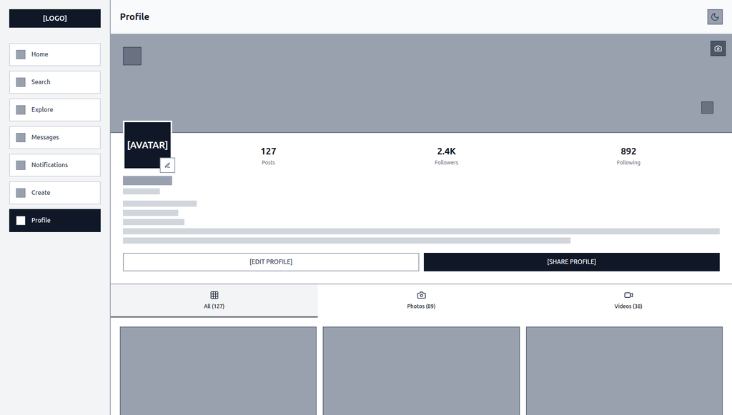

Profil utilisateur — wireframe

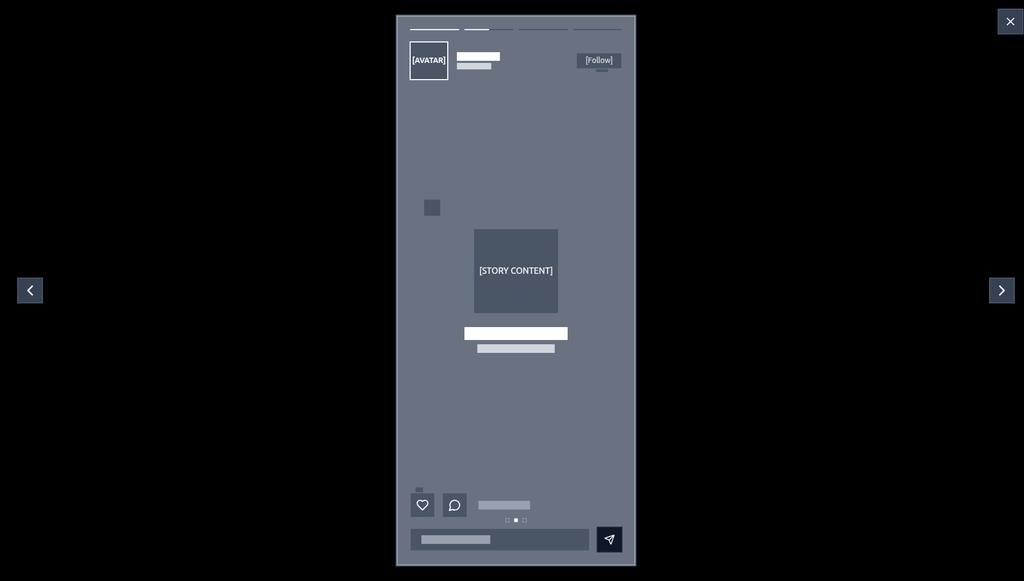

Visionneuse de stories — wireframe

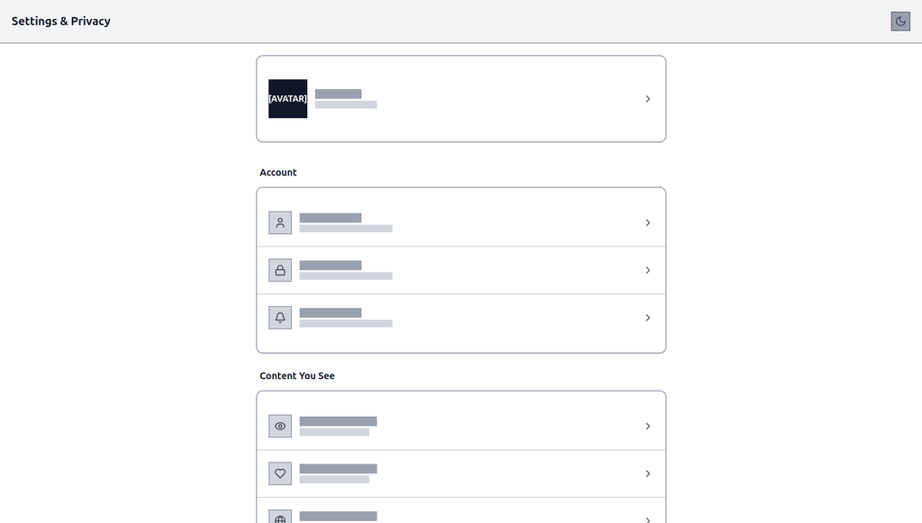

Paramètres — wireframe

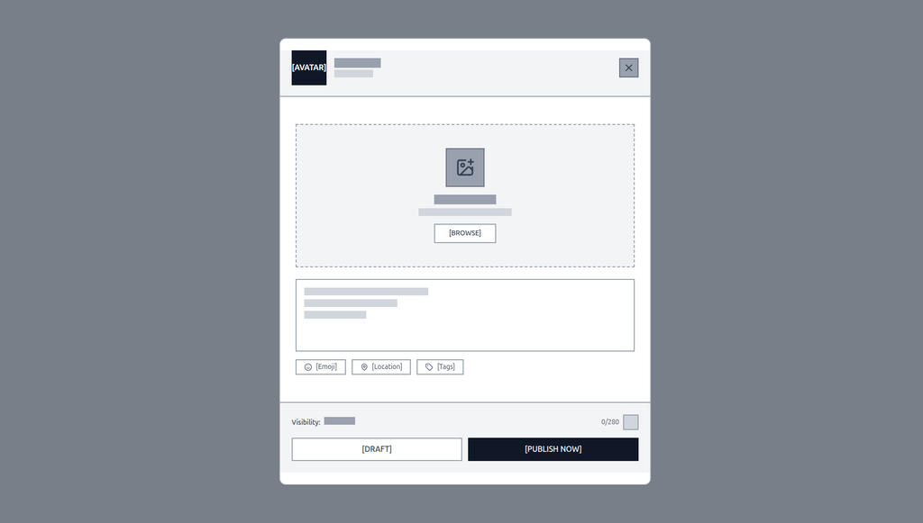

Création de post — wireframe

### Maquettes haute-fidélité

[figure not shown]

Connexion — maquette

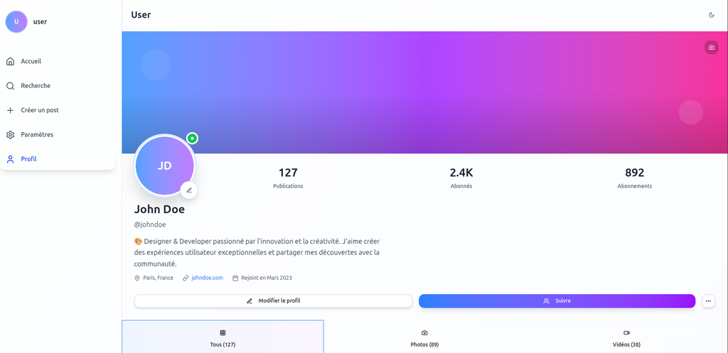

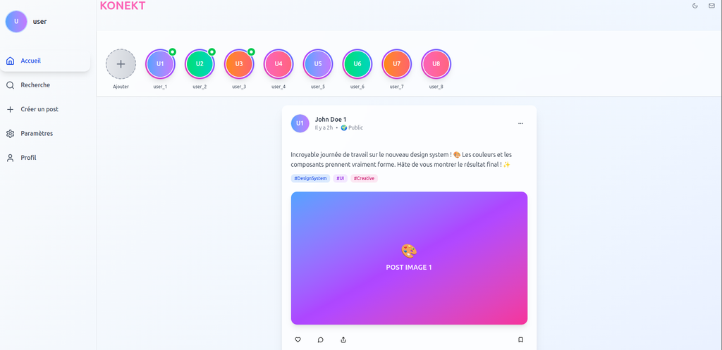

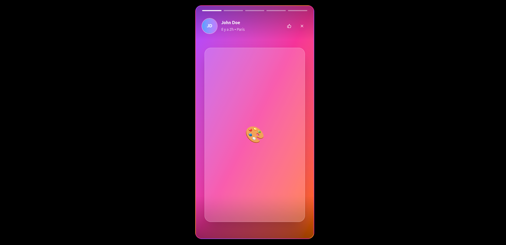

Visionneuse de stories — maquette

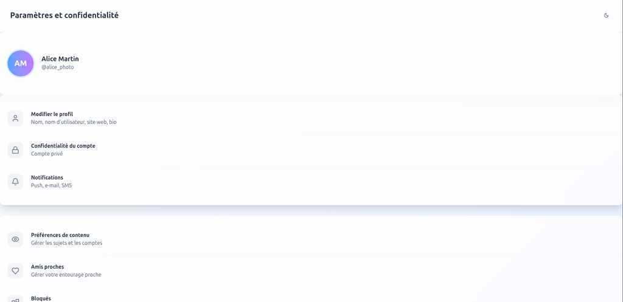

Paramètres — maquette

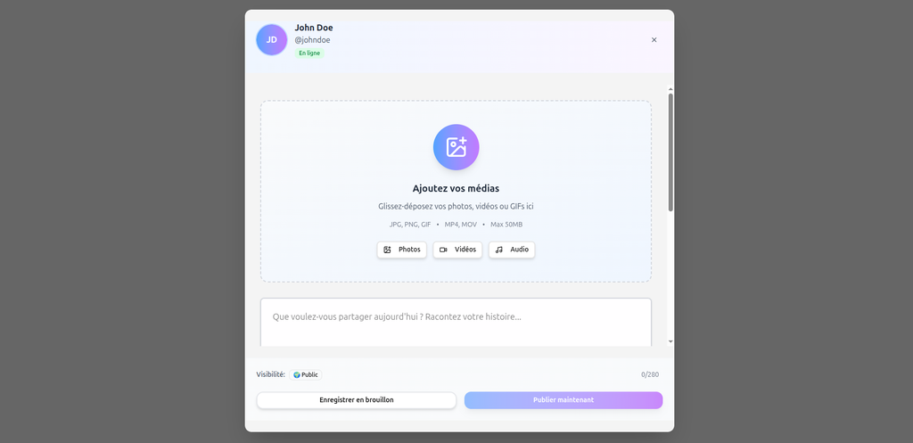

Création de post — maquette

## Checklist Conception

- Pages principales documentées (14 routes)
- Dictionnaire de données complet (18 modèles Prisma)
- Diagrammes MCD/MLD/MPD
- User stories (38+ stories avec critères d’acceptation)
- Design system défini (palette, typographie, breakpoints, composants)
- Architecture data flow documentée
- Wireframes basse-fidélité (07-annexes)
- Maquettes haute-fidélité (07-annexes)
- User flows décrits par fonctionnalité

## Fichiers Liés

- **Introduction:** 01-introduction/README.md
- **Cahier des charges:** 02-cahier-des-charges/README.md
- **Développement:** 04-developpement/README.md
- **Code source:** `/src`
- **Prisma Schema:** `/prisma/schema.prisma`

**Last Updated:** 2026-05-19  
**Version:** 2.0

# User Stories & Cas d’Usage

## Vue d’Ensemble

Nous décrivons ci-dessous les user stories que nous avons rédigées et priorisées pour le projet. Le texte est rédigé à la première personne du pluriel pour refléter notre travail d’équipe et permettre d’indexer facilement chaque story sur les issues/PRs correspondantes du dépôt GitHub.

## Preuves & Mapping GitHub

Nous avons lié les fonctionnalités principales aux tickets du dépôt `arocchet/social-network` :

- Follow / friendship
- Groups & Events
- Group feed (posts in groups)
- Chat system
- Notifications
- DevOps / Docker / CI
- CI pipeline (lint/test/build)
- Seed script / demo data
- Mark notification as read
- OAuth (Google)
- Internationalization (i18n)
- Settings
- PR stabilisation (Docker/Neon/Prisma/Redis)

## Utilisateur Classique (Regular User)

### Authentification & Profil

#### US001: Créer un compte

- **As a** nouvel utilisateur
- **I want to** créer un compte avec email/password
- **So that** je peux accéder au réseau social
- **Acceptance Criteria:**
  - Formulaire d’inscription avec email/password
  - Validation email (pas de doublons)
  - Password strength checker
  - Confirmation email (optionnel)
  - Auto-login après inscription
  - Redirection vers onboarding

#### US002: Compléter le profil

- **As a** nouvel utilisateur
- **I want to** compléter mon profil avec avatar, bio, date de naissance
- **So that** ma présence est visible aux autres

#### US003: Se connecter

- **As a** utilisateur inscrit
- **I want to** me connecter avec email/username et password
- **So that** j’accède à mon compte
- **Acceptance Criteria:**
  - Login avec email OU username
  - JWT token en cookie HTTP-only
  - Session persistent
  - Remember me (7 jours)

#### US004: Consulter mon profil

- **As a** utilisateur connecté
- **I want to** voir mon profil public
- **So that** je vérifie mes informations visibles
- **Acceptance Criteria:**
  - Avatar, banner, bio
  - Statistiques (followers, following, posts)
  - Bouton edit profil

#### US005: Éditer mon profil

- **As a** utilisateur
- **I want to** modifier mes données (nom, bio, avatar, banner)
- **So that** mon profil est à jour
- **Acceptance Criteria:**
  - Modify firstname, lastname, username, bio
  - Upload avatar/banner
  - Prévisualisation
  - Confirmation de modification

#### US006: Gérer les paramètres

- **As a** utilisateur
- **I want to** accéder aux paramètres (notifications, sécurité, langue)
- **So that** je contrôle mon expérience
- **Acceptance Criteria:**
  - Theme toggle (light/dark)
  - Langue (EN/FR)
  - Notifications (push, email)
  - Confidentialité (public/private)
  - Mots de passe à proximité
  - 2FA optionnel

### Posts & Contenu

#### US007: Créer un post

- **As a** utilisateur connecté
- **I want to** publier un post avec texte ±images
- **So that** je partage mon contenu
- **Acceptance Criteria:**
  - Texte uniquement
  - Texte + image
  - Vidéo YouTube embed
  - Sélectionneur de visibilité (PUBLIC/PRIVATE/FRIENDS)
  - Draft auto-save
  - Vérification avant publication

#### US008: Voir le feed

- **As a** utilisateur connecté
- **I want to** voir les posts des utilisateurs que je follow
- **So that** je reste au courant
- **Acceptance Criteria:**
  - Infinite scroll pagination
  - Posts ordonnés par datetime DESC
  - Avatar + nom auteur
  - Affichage images/vidéos
  - Like count, comment count
  - Filtrer par friend only (optionnel)

#### US009: Liker un post

- **As a** utilisateur
- **I want to** liker un post en cliquant sur l’icône
- **So that** j’exprime mon appréciation
- **Acceptance Criteria:**
  - Toggle like/unlike
  - Update like count en temps réel
  - Icône change de couleur
  - Only 1 like par user/post

#### US010: Réagir à un post

- **As a** utilisateur
- **I want to** utiliser des reactions (Love, Wow, Laugh, Sad, Angry)
- **So that** j’exprime différentes émotions
- **Acceptance Criteria:**
  - Menu de 7 reactions
  - Only 1 reaction par user/post
  - Replace like avec reaction
  - Affichage des reactions populaires

#### US011: Commenter un post

- **As a** utilisateur
- **I want to** ajouter un commentaire sur un post
- **So that** je participe à la discussion
- **Acceptance Criteria:**
  - Texte + optionnel images
  - Timestamp
  - Author info (avatar, nom)
  - Like sur commentaires
  - Réponses à commentaires (thread)

#### US012: Supprimer mon post

- **As a** propriétaire d’un post
- **I want to** supprimer mon post
- **So that** je contrôle mon contenu
- **Acceptance Criteria:**
  - Only le propriétaire peut supprimer
  - Confirmation avant suppression
  - Supprime aussi commentaires/reactions
  - Update feed immédiat

#### US013: Partager un post

- **As a** utilisateur
- **I want to** partager un post sur ma timeline
- **So that** mes amis voient ce contenu
- **Acceptance Criteria:**
  - Share button
  - Crée un nouveau post avec citation du post original
  - Garde lien vers original

### Stories

#### US014: Créer une story

- **As a** utilisateur
- **I want to** partager une story (24h duration)
- **So that** je partage des moments éphémères
- **Acceptance Criteria:**
  - Photo/vidéo upload
  - Filtre texte optionnel
  - Visibilité (PUBLIC/FRIENDS)
  - Auto-delete après 24h
  - Privacy: only followers

#### US015: Voir les stories

- **As a** utilisateur
- **I want to** voir les stories des utilisateurs que je follow
- **So that** je suis actif dans le réseau
- **Acceptance Criteria:**
  - Carousel en haut du feed
  - Stories chronologiques (oldest → newest)
  - Affiche seen/unseen count
  - Avatar avec badge vert (unseen)

#### US016: Interagir avec une story

- **As a** utilisateur
- **I want to** liker ou commenter une story
- **So that** j’interagis avec le contenu
- **Acceptance Criteria:**
  - Like button
  - React avec emojis
  - Voir likes/comments count

### Amitié & Suivi

#### US017: Suivre un utilisateur

- **As a** utilisateur
- **I want to** suivre (follow) un autre utilisateur
- **So that** je vois ses posts dans mon feed
- **Acceptance Criteria:**
  - Follow button sur profil
  - Toggle follow/unfollow
  - Counter updated
  - Follow = voir tous posts PUBLIC/FRIENDS

#### US018: Demander en amitié

- **As a** utilisateur
- **I want to** envoyer une demande d’amitié
- **So that** on devienne amis
- **Acceptance Criteria:**
  - Add friend button
  - Status PENDING → ACCEPTED
  - Notification reçue
  - Only amis = voir PRIVATE posts

#### US019: Accepter demande d’amitié

- **As a** utilisateur
- **I want to** accepter une demande d’amitié
- **So that** je confirm la relation
- **Acceptance Criteria:**
  - Voir liste demandes
  - Accept/Decline buttons
  - Notification à l’autre user
  - Add to friends list

#### US020: Consulter mes amis

- **As a** utilisateur
- **I want to** voir ma liste d’amis
- **So that** je gère mes relations
- **Acceptance Criteria:**
  - Affiche tous les amis
  - Avatar + nom
  - Last seen
  - Remove friend option

### Messagerie

#### US021: Envoyer un message direct

- **As a** utilisateur
- **I want to** envoyer un message privé à un autre utilisateur
- **So that** on communique 1-to-1
- **Acceptance Criteria:**
  - Accès depuis profil/friends
  - Message ±image
  - Status: SENT → DELIVERED → READ
  - SSE / polling real-time
  - Typing indicator

#### US022: Voir liste des conversations

- **As a** utilisateur
- **I want to** voir toutes mes conversations
- **So that** je gère mes DMs
- **Acceptance Criteria:**
  - List toutes conversations
  - Last message preview
  - Unread badge
  - Search conversations
  - Sort par recent
  - SSE notifications

#### US023: Archiver une conversation

- **As a** utilisateur
- **I want to** archiver une conversation
- **So that** ma liste reste organisée
- **Acceptance Criteria:**
  - Archive action
  - Hidden from main list
  - Restaurable depuis archive

### Recherche

#### US024: Rechercher des utilisateurs

- **As a** utilisateur
- **I want to** chercher d’autres utilisateurs par nom/username
- **So that** je trouve des gens à follow
- **Acceptance Criteria:**
  - Search bar en haut
  - Debounced search
  - Results: avatar, nom, bio, follow button
  - Recent searches saved

#### US025: Rechercher des posts

- **As a** utilisateur
- **I want to** chercher des posts par mots-clés
- **So that** je trouve du contenu pertinent
- **Acceptance Criteria:**
  - Full-text search
  - Results: author, date, like count
  - Filter par date, author

### Notifications

#### US026: Recevoir notifications

- **As a** utilisateur
- **I want to** être notifié des actions (like, comment, follow, message)
- **So that** je reste engagé
- **Acceptance Criteria:**
  - Notifications temps réel via SSE/Redis
  - Badge sur icône notifs

#### US027: Consulter notifications

- **As a** utilisateur
- **I want to** voir ma liste de notifications
- **So that** je vérifie les actions
- **Acceptance Criteria:**
  - List notifications
  - Mark as read/unread
  - Filter par type
  - Timestamp

### Groupes (Communities)

#### US028: Créer un groupe

- **As a** utilisateur
- **I want to** créer un groupe privé/public
- **So that** je crée une communauté
- **Acceptance Criteria:**
  - Nom + description
  - Avatar groupe
  - Visibilité (PUBLIC/PRIVATE)
  - Creator = owner
  - Invite members

#### US029: Rejoindre un groupe

- **As a** utilisateur
- **I want to** rejoindre un groupe public
- **So that** j’accède au contenu
- **Acceptance Criteria:**
  - Auto-join si PUBLIC
  - Request if PRIVATE
  - Owner approval
  - Add to my groups

#### US030: Voir groupe détails

- **As a** utilisateur
- **I want to** voir les infos d’un groupe
- **So that** je sais ce que c’est
- **Acceptance Criteria:**
  - Nom + description
  - Membres list
  - Events tab
  - Chat tab
  - Settings (owner only)

#### US031: Inviter dans groupe

- **As a** group owner
- **I want to** inviter des utilisateurs
- **So that** elles rejoignent le groupe
- **Acceptance Criteria:**
  - Select users
  - Send invite
  - Notification reçue
  - Accept/decline

#### US032: Communiquer dans groupe

- **As a** membre groupe
- **I want to** envoyer des messages dans le groupe
- **So that** on collabore
- **Acceptance Criteria:**
  - Group chat (comme DM)
  - All members voient
  - Typing indicator
  - Attachments (images)

### Événements (Events)

#### US033: Créer un événement

- **As a** group owner
- **I want to** créer un événement dans le groupe
- **So that** on organise une activité
- **Acceptance Criteria:**
  - Titre + description
  - Date/heure
  - Location (text)
  - Creator = attendee YES

#### US034: Consulter événements

- **As a** utilisateur
- **I want to** voir les événements de mes groupes
- **So that** je vois le calendrier
- **Acceptance Criteria:**
  - List view + calendar
  - Filter (upcoming, past, my events)
  - Event details: title, date, members attending
  - RSVP count

#### US035: RSVP événement

- **As a** utilisateur
- **I want to** répondre à un événement (YES/NO/MAYBE)
- **So that** l’organisateur sait combien attendus
- **Acceptance Criteria:**
  - 3 options: YES, NO, MAYBE
  - Change response
  - Affiche attendees
  - Push notif 24h avant

### Reels (Vidéos)

#### US036: Partager une vidéo

- **As a** utilisateur
- **I want to** partager une vidéo courte
- **So that** je crée du contenu engageant
- **Acceptance Criteria:**
  - Video upload
  - Auto-trim si > 60s
  - Thumbnail generation
  - Published dans /reels

#### US037: Regarder reels

- **As a** utilisateur
- **I want to** scroller verticalement des vidéos
- **So that** je découvre du contenu (TikTok style)
- **Acceptance Criteria:**
  - Fullscreen vertical video
  - Infinite scroll
  - Auto-play next
  - Pause on scroll out

#### US038: Interagir avec reel

- **As a** utilisateur
- **I want to** liker/commenter une vidéo
- **So that** j’engage avec le créateur
- **Acceptance Criteria:**
  - Like button floating
  - Comment button
  - Share button
  - Creator info (link to profile)

## Priorités & Estimation

[output not shown]

### Phase 2: Features (SHOULD HAVE) - 2 semaines

- US010, US014, US017, US018, US028, US033, US036

### Phase 3: Polish (NICE TO HAVE) - 1 semaine

- US013, US016, US023

## Acceptance Criteria Summary

**Front-End:**

- Responsive design (mobile, tablet, desktop)
- Theme switcher (light/dark)
- Loading states + error handling
- Infinite scroll pagination
- Real-time updates (SSE / Redis)
- Image optimization (Cloudinary)
- SEO optimization (meta tags)
- Accessibility (WCAG 2.1 AA)

**Back-End:**

- JWT authentication
- Input validation + sanitization
- Error logging
- Database indexes

**DevOps:**

- Docker containerization
- CI/CD pipeline (GitHub Actions)

## Prochaines Étapes

1. User stories écrites
2. Wireframes créés pour le projet
3. Prototype Figma du projet
4. Validation avec l’équipe
5. Sprint planning
6. Implémentation Phase 1

# Modélisation de Données

## Dictionnaire de Données

Source : `prisma/schema.prisma` — traduit en types SQL PostgreSQL.

**Conventions de types :**

| Type SQL | Description |
| --- | --- |
| `CHAR(25)` | Identifiant CUID (chaîne fixe 25 caractères) |
| `VARCHAR(255)` | Chaîne courte (nom, URL, token) |
| `TEXT` | Chaîne longue (message, biographie) |
| `TIMESTAMP` | Date et heure |
| `BOOLEAN` | Vrai / Faux |
| `BIGINT` | Entier 64 bits (timestamp OAuth) |
| `ENUM(...)` | Valeur parmi un ensemble fini |

## Model: User

**Description :** Entité centrale représentant un utilisateur du réseau social.

### Attributs

| Attribut | Type SQL | Contraintes | Description |
| --- | --- | --- | --- |
| id | CHAR(25) | PRIMARY KEY, NOT NULL | Identifiant CUID |
| firstName | VARCHAR(255) | NULL | Prénom |
| lastName | VARCHAR(255) | NULL | Nom de famille |
| password | VARCHAR(255) | NULL | Hash bcrypt du mot de passe |
| email | VARCHAR(255) | UNIQUE, NOT NULL | Adresse email |
| birthDate | TIMESTAMP | NULL | Date de naissance |
| username | VARCHAR(50) | UNIQUE, NULL | Pseudonyme |
| biography | TEXT | NULL | Biographie |
| avatar | TEXT | NULL | URL avatar (Cloudinary) |
| avatarId | VARCHAR(255) | NULL | ID asset Cloudinary |
| banner | TEXT | NULL | URL bannière (Cloudinary) |
| bannerId | VARCHAR(255) | NULL | ID asset Cloudinary |
| visibility | ENUM(‘PUBLIC’,‘PRIVATE’) | DEFAULT ‘PUBLIC’, NOT NULL | Visibilité du profil |

### Relations

- `posts` : Post[] — Posts créés
- `comments` : Comment[] — Commentaires
- `friendships` : Friendship[] — Amitiés initiées
- `friendsWithMe` : Friendship[] — Amitiés reçues
- `conversations` : Conversation[] — Conversations créées
- `conversationMembers` : ConversationMember[] — Participations aux conversations
- `messages` : Message[] (SentMessages) — Messages envoyés
- `receivedMessages` : Message[] — Messages reçus
- `notifications` : Notification[] — Notifications reçues
- `reactions` : Reaction[] — Réactions publiées
- `stories` : Story[] — Stories publiées
- `rsvps` : Rsvp[] — Réponses aux événements
- `groupInvitations` : GroupInvitation[] (invitant + invité)
- `groupMembers` : GroupMember[] — Adhésions aux groupes
- `groupMessages` : GroupMessage[] — Messages de groupe
- `eventsCreated` : Event[] — Événements créés
- `userSettings` : UserSettings — Préférences
- `accounts` : Account[] — Comptes OAuth (Google)

## Model: Post

**Description :** Publication sur le fil d’actualité (texte, image, vidéo).

### Attributs

| Attribut | Type SQL | Contraintes | Description |
| --- | --- | --- | --- |
| id | CHAR(25) | PRIMARY KEY, NOT NULL | Identifiant CUID |
| userId | CHAR(25) | FOREIGN KEY (User), NOT NULL | Auteur du post |
| message | TEXT | NOT NULL | Contenu textuel |
| datetime | TIMESTAMP | DEFAULT NOW(), NOT NULL | Date de publication |
| image | TEXT | NULL | URL image (Cloudinary) |
| mediaId | VARCHAR(255) | NULL | ID asset Cloudinary |
| visibility | ENUM(‘PUBLIC’,‘PRIVATE’,‘FRIENDS’) | DEFAULT ‘PUBLIC’, NOT NULL | Visibilité du post |

### Enum

- `Visibility` : PUBLIC, PRIVATE, FRIENDS

### Relations

- `user` : User — Auteur
- `comments` : Comment[] — Commentaires
- `reactions` : Reaction[] — Réactions

## Model: Comment

**Description :** Commentaire posté sur un Post.

### Attributs

| Attribut | Type SQL | Contraintes | Description |
| --- | --- | --- | --- |
| id | CHAR(25) | PRIMARY KEY, NOT NULL | Identifiant CUID |
| postId | CHAR(25) | FOREIGN KEY (Post), NOT NULL | Post parent |
| userId | CHAR(25) | FOREIGN KEY (User), NOT NULL | Auteur |
| message | TEXT | NOT NULL | Contenu |
| datetime | TIMESTAMP | DEFAULT NOW(), NOT NULL | Date de création |

### Relations

- `post` : Post
- `user` : User
- `reactions` : Reaction[]

## Model: Reaction

**Description :** Réaction d’un utilisateur sur un Post, une Story ou un Comment.

### Attributs

| Attribut | Type SQL | Contraintes | Description |
| --- | --- | --- | --- |
| id | CHAR(25) | PRIMARY KEY, NOT NULL | Identifiant CUID |
| type | ENUM(‘LIKE’,‘DISLIKE’,‘LOVE’,‘LAUGH’,‘SAD’,‘ANGRY’,‘WOW’) | NOT NULL | Type de réaction |
| userId | CHAR(25) | FOREIGN KEY (User), NOT NULL | Auteur |
| postId | CHAR(25) | FOREIGN KEY (Post), NULL | Post ciblé |
| storyId | CHAR(25) | FOREIGN KEY (Story), NULL | Story ciblée |
| commentId | CHAR(25) | FOREIGN KEY (Comment), NULL | Commentaire ciblé |
| datetime | TIMESTAMP | DEFAULT NOW(), NOT NULL | Date |

### Contraintes d’unicité

- `(userId, postId)` — une réaction par utilisateur par post
- `(userId, storyId)` — une réaction par utilisateur par story
- `(userId, commentId)` — une réaction par utilisateur par commentaire

### Relations

- `user` : User
- `post` : Post (nullable)
- `story` : Story (nullable)
- `comment` : Comment (nullable)

## Model: Message

**Description :** Message privé direct entre deux utilisateurs (1-to-1).

### Attributs

| Attribut | Type SQL | Contraintes | Description |
| --- | --- | --- | --- |
| id | CHAR(25) | PRIMARY KEY, NOT NULL | Identifiant CUID |
| senderId | CHAR(25) | FOREIGN KEY (User), NOT NULL | Expéditeur |
| receiverId | CHAR(25) | FOREIGN KEY (User), NOT NULL | Destinataire |
| message | TEXT | NOT NULL | Contenu |
| image | TEXT | NULL | URL image attachée |
| datetime | TIMESTAMP | DEFAULT NOW(), NOT NULL | Date d’envoi |
| deliveredAt | TIMESTAMP | NULL | Date de livraison |
| readAt | TIMESTAMP | NULL | Date de lecture |
| status | ENUM(‘SENT’,‘DELIVERED’,‘READ’) | DEFAULT ‘SENT’, NOT NULL | Statut du message |

### Relations

- `sender` : User
- `receiver` : User

## Model: Friendship

**Description :** Relation d’amitié entre deux utilisateurs.

### Attributs

| Attribut | Type SQL | Contraintes | Description |
| --- | --- | --- | --- |
| id | CHAR(25) | PRIMARY KEY, NOT NULL | Identifiant CUID |
| userId | CHAR(25) | FOREIGN KEY (User), NOT NULL | Demandeur |
| friendId | CHAR(25) | FOREIGN KEY (User), NOT NULL | Destinataire |
| status | ENUM(‘PENDING’,‘ACCEPTED’) | NOT NULL | Statut de la demande |
| createdAt | TIMESTAMP | DEFAULT NOW(), NOT NULL | Date de création |

### Contrainte d’unicité

- `(userId, friendId)` — pas de doublon de relation

### Relations

- `user` : User (demandeur)
- `friend` : User (ami)

## Model: Story

**Description :** Contenu éphémère publié par un utilisateur.

### Attributs

| Attribut | Type SQL | Contraintes | Description |
| --- | --- | --- | --- |
| id | CHAR(25) | PRIMARY KEY, NOT NULL | Identifiant CUID |
| userId | CHAR(25) | FOREIGN KEY (User), NOT NULL | Créateur |
| datetime | TIMESTAMP | DEFAULT NOW(), NOT NULL | Date de publication |
| media | TEXT | NULL | URL média (Cloudinary) |
| mediaId | VARCHAR(255) | NULL | ID asset Cloudinary |
| visibility | ENUM(‘PUBLIC’,‘PRIVATE’,‘FRIENDS’) | DEFAULT ‘PUBLIC’, NOT NULL | Visibilité |

### Relations

- `user` : User
- `reactions` : Reaction[]

## Model: Conversation

**Description :** Conversation de groupe ou wrapper DM.

### Attributs

| Attribut | Type SQL | Contraintes | Description |
| --- | --- | --- | --- |
| id | CHAR(25) | PRIMARY KEY, NOT NULL | Identifiant CUID |
| title | VARCHAR(255) | NULL | Nom du groupe |
| isGroup | BOOLEAN | DEFAULT FALSE, NOT NULL | Est un groupe |
| createdAt | TIMESTAMP | DEFAULT NOW(), NOT NULL | Date de création |
| ownerId | CHAR(25) | FOREIGN KEY (User), NULL | Propriétaire du groupe |

### Relations

- `owner` : User (nullable)
- `members` : ConversationMember[]
- `messages` : GroupMessage[]
- `events` : Event[]
- `groupInvitations` : GroupInvitation[]
- `groupMembers` : GroupMember[]
- `groupJoinRequests` : GroupJoinRequest[]

## Model: ConversationMember

**Description :** Participant à une conversation.

### Attributs

| Attribut | Type SQL | Contraintes | Description |
| --- | --- | --- | --- |
| id | CHAR(25) | PRIMARY KEY, NOT NULL | Identifiant CUID |
| userId | CHAR(25) | FOREIGN KEY (User), NOT NULL | Utilisateur |
| conversationId | CHAR(25) | FOREIGN KEY (Conversation), NOT NULL | Conversation |
| joinedAt | TIMESTAMP | DEFAULT NOW(), NOT NULL | Date d’adhésion |
| lastSeenAt | TIMESTAMP | NULL | Dernier accès |
| lastSeenMessageId | CHAR(25) | NULL | Dernier message vu |

### Contrainte d’unicité

- `(userId, conversationId)` — pas de doublon

## Model: GroupMessage

**Description :** Message dans une conversation de groupe.

### Attributs

| Attribut | Type SQL | Contraintes | Description |
| --- | --- | --- | --- |
| id | CHAR(25) | PRIMARY KEY, NOT NULL | Identifiant CUID |
| conversationId | CHAR(25) | FOREIGN KEY (Conversation), NOT NULL | Conversation parente |
| senderId | CHAR(25) | FOREIGN KEY (User), NOT NULL | Expéditeur |
| message | TEXT | NOT NULL | Contenu |
| image | TEXT | NULL | URL image |
| sentAt | TIMESTAMP | DEFAULT NOW(), NOT NULL | Date d’envoi |
| eventId | CHAR(25) | FOREIGN KEY (Event), NULL | Événement associé |
| deliveredAt | TIMESTAMP | NULL | Date de livraison |
| readAt | TIMESTAMP | NULL | Date de lecture |
| status | ENUM(‘SENT’,‘DELIVERED’,‘READ’) | DEFAULT ‘SENT’, NOT NULL | Statut |

## Model: GroupInvitation

**Description :** Invitation d’un utilisateur à rejoindre un groupe.

### Attributs

| Attribut | Type SQL | Contraintes | Description |
| --- | --- | --- | --- |
| id | CHAR(25) | PRIMARY KEY, NOT NULL | Identifiant CUID |
| groupId | CHAR(25) | FOREIGN KEY (Conversation), NOT NULL | Groupe cible |
| inviterId | CHAR(25) | FOREIGN KEY (User), NOT NULL | Invitant |
| invitedId | CHAR(25) | FOREIGN KEY (User), NOT NULL | Invité |
| status | ENUM(‘PENDING’,‘ACCEPTED’) | DEFAULT ‘PENDING’, NOT NULL | Statut |
| createdAt | TIMESTAMP | DEFAULT NOW(), NOT NULL | Date de création |

### Contrainte d’unicité

- `(groupId, invitedId)` — pas de doublon

## Model: GroupJoinRequest

**Description :** Demande spontanée d’adhésion à un groupe.

### Attributs

| Attribut | Type SQL | Contraintes | Description |
| --- | --- | --- | --- |
| id | CHAR(25) | PRIMARY KEY, NOT NULL | Identifiant CUID |
| groupId | CHAR(25) | FOREIGN KEY (Conversation), NOT NULL | Groupe cible |
| seeker | CHAR(25) | FOREIGN KEY (User), NOT NULL | Demandeur |
| status | ENUM(‘PENDING’,‘ACCEPTED’) | DEFAULT ‘PENDING’, NOT NULL | Statut |
| createdAt | TIMESTAMP | DEFAULT NOW(), NOT NULL | Date de création |

### Contrainte d’unicité

- `(groupId, seeker)` — pas de doublon

## Model: GroupMember

**Description :** Adhésion confirmée d’un utilisateur à un groupe.

### Attributs

| Attribut | Type SQL | Contraintes | Description |
| --- | --- | --- | --- |
| id | CHAR(25) | PRIMARY KEY, NOT NULL | Identifiant CUID |
| groupId | CHAR(25) | FOREIGN KEY (Conversation), NOT NULL | Groupe |
| userId | CHAR(25) | FOREIGN KEY (User), NOT NULL | Membre |
| joinedAt | TIMESTAMP | DEFAULT NOW(), NOT NULL | Date d’adhésion |

### Contrainte d’unicité

- `(groupId, userId)` — pas de doublon

## Model: Event

**Description :** Événement créé dans un groupe, avec RSVP.

### Attributs

| Attribut | Type SQL | Contraintes | Description |
| --- | --- | --- | --- |
| id | CHAR(25) | PRIMARY KEY, NOT NULL | Identifiant CUID |
| title | VARCHAR(255) | NOT NULL | Titre |
| description | TEXT | NOT NULL | Description |
| datetime | TIMESTAMP | NOT NULL | Date/heure |
| groupId | CHAR(25) | FOREIGN KEY (Conversation), NOT NULL | Groupe hôte |
| ownerId | CHAR(25) | FOREIGN KEY (User), NOT NULL | Créateur |
| createdAt | TIMESTAMP | DEFAULT NOW(), NOT NULL | Date de création |

### Relations

- `group` : Conversation
- `owner` : User
- `messages` : GroupMessage[]
- `rsvps` : Rsvp[]

## Model: Rsvp

**Description :** Réponse d’un utilisateur à un événement.

### Attributs

| Attribut | Type SQL | Contraintes | Description |
| --- | --- | --- | --- |
| id | CHAR(25) | PRIMARY KEY, NOT NULL | Identifiant CUID |
| userId | CHAR(25) | FOREIGN KEY (User), NOT NULL | Utilisateur |
| eventId | CHAR(25) | FOREIGN KEY (Event), NOT NULL | Événement |
| status | ENUM(‘YES’,‘NO’,‘MAYBE’) | NOT NULL | Réponse |
| createdAt | TIMESTAMP | DEFAULT NOW(), NOT NULL | Date de réponse |

### Contrainte d’unicité

- `(userId, eventId)` — un RSVP par utilisateur par événement

## Model: UserSettings

**Description :** Préférences de l’utilisateur (thème, langue, notifications).

### Attributs

| Attribut | Type SQL | Contraintes | Description |
| --- | --- | --- | --- |
| id | CHAR(25) | PRIMARY KEY, NOT NULL | Identifiant CUID |
| userId | CHAR(25) | UNIQUE, FOREIGN KEY (User), NOT NULL | Utilisateur (1-to-1) |
| theme | VARCHAR(10) | DEFAULT ‘light’, NOT NULL | Thème (light / dark) |
| language | VARCHAR(10) | DEFAULT ‘en’, NOT NULL | Code langue (en, fr) |
| notificationsEnabled | BOOLEAN | DEFAULT TRUE, NOT NULL | Notifications actives |
| createdAt | TIMESTAMP | DEFAULT NOW(), NOT NULL | Date de création |

## Model: Notification

**Description :** Notification système envoyée à un utilisateur.

### Attributs

| Attribut | Type SQL | Contraintes | Description |
| --- | --- | --- | --- |
| id | CHAR(25) | PRIMARY KEY, NOT NULL | Identifiant CUID |
| userId | CHAR(25) | FOREIGN KEY (User), NOT NULL | Destinataire |
| type | VARCHAR(50) | NOT NULL | Type d’événement |
| message | TEXT | NOT NULL | Contenu |
| isRead | BOOLEAN | DEFAULT FALSE, NOT NULL | Lue ou non |
| createdAt | TIMESTAMP | DEFAULT NOW(), NOT NULL | Date de création |

### Index

- `userId` — accès rapide aux notifications par utilisateur

## Model: Account

**Description :** Compte OAuth lié à un utilisateur (Google).

### Attributs

| Attribut | Type SQL | Contraintes | Description |
| --- | --- | --- | --- |
| id | CHAR(25) | PRIMARY KEY, NOT NULL | Identifiant CUID |
| userId | CHAR(25) | FOREIGN KEY (User), NOT NULL | Utilisateur propriétaire |
| provider | VARCHAR(50) | NOT NULL | Fournisseur (google…) |
| providerAccountId | VARCHAR(255) | NOT NULL | ID chez le fournisseur |
| refresh_token | TEXT | NULL | Token de rafraîchissement |
| access_token | TEXT | NULL | Token d’accès |
| expires_at | BIGINT | NULL | Expiration (epoch ms) |
| token_type | VARCHAR(50) | NULL | Type de token |
| scope | TEXT | NULL | Permissions accordées |
| id_token | TEXT | NULL | ID token JWT |
| session_state | VARCHAR(255) | NULL | État de session |

### Contrainte d’unicité

- `(provider, providerAccountId)` — un compte par fournisseur

## MLD — Modèle Logique de Données

```
User          (id, firstName, lastName, password, email, birthDate, username, biography, avatar, avatarId, banner, bannerId, visibility)
Account       (id, userId#, provider, providerAccountId, refresh_token, access_token, expires_at, token_type, scope, id_token, session_state)
Post          (id, userId#, message, datetime, image, mediaId, visibility)
Comment       (id, postId#, userId#, message, datetime)
Reaction      (id, type, userId#, postId#, storyId#, commentId#, datetime)
Story         (id, userId#, datetime, media, mediaId, visibility)
Message       (id, senderId#, receiverId#, message, image, datetime, deliveredAt, readAt, status)
Friendship    (id, userId#, friendId#, status, createdAt)
Conversation  (id, title, isGroup, createdAt, ownerId#)
ConversationMember  (id, userId#, conversationId#, joinedAt, lastSeenAt, lastSeenMessageId)
GroupMessage  (id, conversationId#, senderId#, message, image, sentAt, eventId#, deliveredAt, readAt, status)
GroupInvitation     (id, groupId#, inviterId#, invitedId#, status, createdAt)
GroupJoinRequest    (id, groupId#, seeker#, status, createdAt)
GroupMember   (id, groupId#, userId#, joinedAt)
Event         (id, title, description, datetime, groupId#, ownerId#, createdAt)
Rsvp          (id, userId#, eventId#, status, createdAt)
UserSettings  (id, userId#, theme, language, notificationsEnabled, createdAt)
Notification  (id, userId#, type, message, isRead, createdAt)
```

> `#` désigne une clé étrangère (FOREIGN KEY).

## Cardinalités

| Relation | Type | Description |
| --- | --- | --- |
| User → Post | 1,N | Un utilisateur publie plusieurs posts |
| User → Comment | 1,N | Un utilisateur écrit plusieurs commentaires |
| User → Reaction | 1,N | Un utilisateur crée plusieurs réactions |
| Post → Comment | 1,N | Un post reçoit plusieurs commentaires |
| Post / Story / Comment → Reaction | 1,N | Chaque entité reçoit plusieurs réactions |
| User → Friendship | 1,N | Un utilisateur a plusieurs relations d’amitié |
| Conversation → GroupMessage | 1,N | Une conversation contient plusieurs messages |
| Conversation → ConversationMember | 1,N | Une conversation a plusieurs participants |
| User → Event | 1,N | Un utilisateur crée plusieurs événements |
| Event → Rsvp | 1,N | Un événement reçoit plusieurs réponses |
| User → UserSettings | 1,1 | Un utilisateur a exactement un paramétrage |
| User → Account | 1,N | Un utilisateur peut avoir plusieurs comptes OAuth |

## Checklist Modélisation

- Dictionnaire de données — types SQL PostgreSQL
- Relations et clés étrangères documentées
- Enums PostgreSQL définis
- Contraintes d’unicité listées
- MLD avec notation clés étrangères
- Cardinalités définies
- Tests de cohérence (contraintes vérifiées via `prisma validate`)

## Diagrammes Complets

Les diagrammes MCD, MLD et MPD en format DBML et SQL sont disponibles dans diagrammes-uml.md.

# 04 - Développement

## Objectif

Documenter l’architecture applicative, les endpoints API, l’authentification, le temps réel et la stratégie de tests/CI.

### Preuves & Mapping GitHub

Les éléments techniques présentés ici sont issus des tickets et PRs du dépôt `arocchet/social-network` (références utiles pour le jury et la revue):

- PR stabilisation (Docker/Neon/Prisma/Redis)
- DevOps / Docker / CI
- Socket/chat system
- Notifications & endpoints
- Database / Prisma migrations

Le socle technique a été stabilisé sur la base de ces sujets GitHub.

## Diagrammes d’Architecture (Mermaid)

### Architecture Système

```
graph LR
  subgraph Client
    Browser["Next.js App Router - SSR/CSR"]
  end

  subgraph CDN
    Vercel["Vercel / Edge CDN"]
  end

  subgraph Backend
    NextAPI["Next.js API Routes"]
    SSE["SSE Endpoints / Polling"]
    Redis["Upstash Redis"]
    Prisma["Prisma Client"]
  end

  subgraph Infra
    Postgres[("PostgreSQL - Neon")]
    Storage[("Cloudinary - media")]
  end

  Browser --> Vercel
  Vercel --> NextAPI
  NextAPI --> Prisma
  Prisma --> Postgres
  NextAPI --> Redis
  SSE --> Redis
  Browser --> SSE
  NextAPI --> Storage
  Browser --> Storage

  classDef infra fill:#f3f4f6,stroke:#ccc;
  class Postgres,Storage infra;
```

### Auth Flow (Login)

```
sequenceDiagram
  participant B as Browser
  participant N as NextJS API
  participant P as Prisma
  participant R as Redis

  B->>N: POST /api/auth/login
  N->>P: SELECT user WHERE email
  P-->>N: user row
  N->>N: verify password + create JWT
  N->>R: store session uuid to userId
  N-->>B: set-cookie HttpOnly JWT, 200 OK
```

### Real-time Messaging Sequence (SSE + Redis Polling)

```
sequenceDiagram
  participant U1 as User A
  participant SSE as SSE Endpoint
  participant API as NextJS API
  participant R as Redis
  participant DB as Postgres

  U1->>API: POST /api/private/chat/send
  API->>DB: INSERT message SENT
  DB-->>API: saved message
  API->>R: SET message TTL 60s
  API-->>U1: ack SENT
  U1->>SSE: GET /api/private/chat/listen
  SSE->>R: GET message keys
  R-->>SSE: message data
  SSE-->>U1: emit message SENT
  U1->>API: mark as read
  API->>DB: UPDATE deliveredAt readAt
```

### Schéma ER (Simplifié)

```
erDiagram
  USER ||--o{ POST : creates
  USER ||--o{ COMMENT : writes
  POST ||--o{ COMMENT : has
  USER ||--o{ REACTION : gives
  POST ||--o{ REACTION : receives
  USER ||--o{ CONVERSATION_MEMBER : participates
  CONVERSATION ||--o{ GROUP_MESSAGE : contains
  CONVERSATION ||--o{ EVENT : hosts
```

## Authentification & Middleware

- Auth via JWT stocké en cookie HTTP-only; refresh tokens optionnels.
- Middleware Next.js valide JWT sur routes protégées (server-side) et redirige vers `/login` si absent/expiré.
- Sessions courtes côté serveur (Redis) pour invalidation forcée et gestion multi-device.

Pattern recommandé:

- `middleware.ts` vérifie cookie, charge user id, attache `request.user` pour handlers.

## Temps réel (Upstash Redis + SSE Polling)

- Architecture: Client poll les endpoints SSE toutes les 500ms via Upstash Redis.
- Evénements principaux (via Redis keys):
  - `message:{conversationId}:{messageId}` → contenu du message
  - `message:status:{messageId}` → SENT / DELIVERED / READ
  - `notification:user:{userId}` → nouvelles notifications
  - `typing:{conversationId}:{userId}` → indicateur de frappe
- Persistance: Prisma → PostgreSQL pour le stockage durable + Redis (60s TTL) pour le temps réel.
- Avantage: Haute disponibilité (pas de connexion persistante), compatible Vercel serverless.

## Endpoints API

**Documentation Complète:** api-spec.md

### Résumé Rapide

**Auth:**

- `POST /api/auth/login` — Connexion
- `POST /api/auth/register` — Inscription
- `POST /api/auth/logout` — Déconnexion

**Users:**

- `GET /api/user/me` — ID utilisateur
- `GET /api/private/me` — Profil complet
- `PUT /api/private/me` — Modifier profil

**Posts:**

- `GET /api/private/post` — Lister posts
- `POST /api/private/post` — Créer post

**Stories:**

- `GET /api/private/stories` — Lister stories
- `POST /api/private/stories` — Créer story

**Messages:**

- `GET /api/private/messages` — Récupérer messages
- `GET /api/private/conversations` — Lister conversations

**Groupes:**

- `GET /api/private/groups` — Lister groupes
- `POST /api/private/groups` — Créer groupe

**Événements:**

- `GET /api/private/events` — Lister événements
- `POST /api/private/events` — Créer événement

**Amitié:**

- `GET /api/private/friend-requests` — Demandes reçues
- `POST /api/private/friend-requests` — Envoyer demande

**Recherche:**

- `GET /api/private/search` — Rechercher users/posts

**Invitations:**

- `GET /api/private/invitations` — Invitations groupe

**→ Voir api-spec.md pour détails complets (payloads, réponses, erreurs).**

## Implémentation - Code Samples

### Authentification (Middleware)

**`src/middleware.ts`** — Valide JWT et charge user ID sur routes protégées:

```typescript
import { NextRequest, NextResponse } from "next/server";

export function middleware(request: NextRequest) {
  const token = request.cookies.get("auth_token")?.value;

  // Redirect to login if no token
  if (!token && request.nextUrl.pathname.startsWith("/api/private")) {
    return NextResponse.json({ error: "Unauthorized" }, { status: 401 });
  }

  // Continue if token exists or public route
  return NextResponse.next();
}

export const config = {
  matcher: ["/api/private/:path*", "/(feed)/:path*"],
};
```

### API Route Sample

**`src/app/api/private/post/route.ts`** — Créer et lister posts:

```typescript
import { NextRequest, NextResponse } from "next/server";
import { getUserIdFromRequest } from "@/lib/server/api/getUserId";
import { respondSuccess, respondError } from "@/lib/server/api/response";

export async function POST(req: NextRequest) {
  const userId = await getUserIdFromRequest(req);
  if (!userId) {
    return NextResponse.json(respondError("Unauthorized"), { status: 401 });
  }

  const formData = await req.formData();
  const message = formData.get("message") as string;
  const image = formData.get("image") as File;

  // Create post in database via Prisma
  const post = await db.post.create({
    data: {
      userId,
      message,
      image: image ? await uploadToCloudinary(image) : null,
      visibility: "PUBLIC",
    },
  });

  return NextResponse.json(respondSuccess(post), { status: 201 });
}
```

### Real-time avec Redis + SSE Polling

**`src/app/api/private/chat/send/route.ts`** — Envoie et stocke messages:

```typescript
import { NextRequest, NextResponse } from "next/server";
import { db } from "@/lib/db";
import { redisdb } from "@/lib/server/websocket/redis";

export async function POST(req: NextRequest) {
  const { senderId, receiverId, message } = await req.json();

  // Persist in database
  const msg = await db.message.create({
    data: { senderId, receiverId, message, status: "SENT" },
  });

  // Store in Redis with 60s TTL for real-time sync
  await redisdb.set(`message:${msg.id}`, JSON.stringify(msg), { ex: 60 });
  await redisdb.set(`message:status:${msg.id}`, "SENT", { ex: 60 });

  return NextResponse.json(msg, { status: 201 });
}
```

**`src/app/api/private/chat/listen/route.ts`** — SSE endpoint pour polling:

```typescript
import { NextRequest } from "next/server";
import { redisdb } from "@/lib/server/websocket/redis";

export async function GET(req: NextRequest) {
  const userId = req.headers.get("x-user-id");

  const stream = new ReadableStream({
    async start(controller) {
      while (true) {
        // Check Redis for new messages every 500ms
        const keys = await redisdb.keys(`message:*`);
        const messages = await Promise.all(keys.map((k) => redisdb.get(k)));

        controller.enqueue(`data: ${JSON.stringify(messages)}\n\n`);
        await new Promise((r) => setTimeout(r, 500));
      }
    },
  });

  return new Response(stream, {
    headers: { "Content-Type": "text/event-stream" },
  });
}
```

## Tests & CI/CD

### Tests

**Stratégie recommandée:**

- Unit tests: Jest + React Testing Library
- Integration tests: Jest + Testing Library for API routes
- Contract tests pour événements temps réel (optionnel)

**Sample test (`__tests__/integrations/auth.test.ts`):**

```typescript
import { POST } from "@/app/api/auth/login/route";

describe("POST /api/auth/login", () => {
  it("should login with valid credentials", async () => {
    const req = new Request(new URL("http://localhost/api/auth/login"), {
      method: "POST",
      body: JSON.stringify({
        email: "test@example.com",
        password: "password123",
      }),
    });

    const response = await POST(req as any);
    expect(response.status).toBe(200);
  });
});
```

### GitHub Actions (CI/CD)

**`.github/workflows/ci.yml`:**

```yaml
name: CI

on: [push, pull_request]

jobs:
  test:
    runs-on: ubuntu-latest
    steps:
      - uses: actions/checkout@v3
      - uses: actions/setup-node@v3
        with:
          node-version: "18"

      - run: npm install
      - run: npm run lint
      - run: npm run test
      - run: npm run build
```

## Structure de Code

### Directories Clés

```
src/
├── app/
│   ├── api/
│   │   ├── auth/          # Endpoints authentification
│   │   ├── private/       # Routes protégées
│   │   │   ├── post/      # Posts CRUD
│   │   │   ├── messages/  # Messages
│   │   │   ├── groups/    # Groupes
│   │   │   ├── events/    # Événements
│   │   │   ├── stories/   # Stories
│   │   │   └── ...
│   │   └── public/        # Routes publiques
│   ├── (feed)/            # Pages feed
│   ├── (auth)/            # Pages auth
│   └── layout.tsx
├── components/
│   ├── feed/              # Post cards, feed
│   ├── chat/              # Messages UI
│   ├── groups/            # Groups UI
│   └── ...
├── hooks/
│   ├── use-api.ts         # Fetch helper
│   ├── use-post-data.ts   # Posts logic
│   ├── use-conversations.ts  # Messages logic
│   └── ...
├── lib/
│   ├── db/                # Prisma client
│   ├── server/            # Server utils
│   │   ├── api/           # API response helpers
│   │   ├── user/          # User queries
│   │   ├── post/          # Post queries
│   │   └── websocket/     # Redis/SSE real-time helpers
│   ├── schemas/           # Zod validators
│   └── utils/             # Helpers
└── middleware.ts          # Auth middleware
```

### Validation & Error Handling

- **Schemas:** Zod + TypeScript interfaces in `src/lib/schemas/`
- **Response Format:** `respondSuccess()` / `respondError()` helpers
- **Status Codes:** 200, 201, 400, 401, 403, 404, 500
- **Validation Errors:** Detailed field errors in response

## Checklist Implémentation

- Auth (JWT + HTTP-only cookies + middleware)
- API routes (60+ endpoints documentés)
- Database (Prisma v6 + 18 modèles + migrations)
- Real-time (SSE + Upstash Redis)
- Error handling (validation Zod + codes HTTP standards)
- File uploads (Cloudinary integration)
- Pagination (infinite scroll + curseur)
- Tests d’intégration (Jest, authentification)
- API documentation complète (api-spec.md)

**Last Updated:** 2026-05-19  
**Version:** 2.0

# Sécurité et conformité RGPD

## Objectif

Cette section répond directement à l’intitulé des **3 blocs RNCP 37873** qui parlent tous d’« application **sécurisée** ». Elle décrit :

1. les mesures de sécurité **réellement implémentées** dans le code (avec références fichiers),
2. les **risques résiduels** identifiés et leur impact,
3. la **conformité RGPD** : ce qui est en place et ce qui reste à faire,
4. la **roadmap** de durcissement.

L’approche est volontairement honnête : tout ce qui est annoncé est vérifiable dans le dépôt ; tout ce qui manque est listé pour ne pas être pris en défaut en soutenance.

## 1. Authentification et sessions

### 1.1 JWT signé via `jose`

**Fichiers :** `src/lib/jwt/signJwt.ts`, `src/lib/jwt/verifyJwt.ts`, `src/config/auth.ts`

- Algorithme : **HS256** (HMAC SHA-256, secret symétrique).
- Secret : variable d’environnement `JWT_SECRET`, jamais committée (référencée dans `.env.example`).
- Payload minimal : `{ userId }` — on évite de mettre l’email ou des données personnelles dans le token.
- Expiration par défaut : **8 heures** (`JWT_EXPIRATION.DEFAULT = "480m"`). Constantes prédéfinies pour 10min, 1h, 1j, 7j, 30j.
- Vérification gérée dans le middleware Next.js et utilitaires serveur ; messages d’erreur normalisés (`Token expired`, `Invalid token`).

### 1.2 Hashage des mots de passe avec bcrypt

**Fichier :** `src/lib/security/hash.ts`

```typescript
import bcrypt from 'bcrypt'

export async function hashPassword(password: string) {
    return await bcrypt.hash(password, 12)
}

export async function comparePasswords(password: string, hashed: string) {
    return await bcrypt.compare(password, hashed)
}
```

- **Cost factor 12** (~250 ms par hash sur CPU moderne) — au-dessus du minimum OWASP (10), résistant aux attaques par force brute.
- Pas de stockage en clair, pas de stockage réversible.
- La comparaison utilise `bcrypt.compare` (résistant au timing attack).

### 1.3 Cookies HTTP-only

**Fichiers :** `src/app/api/public/auth/login/route.ts`, `register/route.ts`, `logout/route.ts`, `callback/google/route.ts`

Tous les cookies d’authentification respectent les flags :

| Flag | Valeur | Effet |
| --- | --- | --- |
| `httpOnly` | `true` | Inaccessible en JavaScript côté client → mitige les attaques XSS |
| `secure` | `true` en production | Cookie transmis uniquement via HTTPS |
| `sameSite` | `lax` | Bloque l’envoi du cookie sur les requêtes cross-site → mitige CSRF |
| `maxAge` | 7 jours (login), 8 h (register, OAuth) | Expiration cohérente avec le JWT |

### 1.4 Middleware d’autorisation par défaut

**Fichier :** `src/middleware.ts`

Pour les routes protégées, il vérifie le cookie `authToken` via `verifyJwt`, redirige vers `/login` si invalide, et **injecte un header `x-user-id`** dans la requête downstream. Les routes API consomment cet identifiant via `getUserIdFromRequest`.

C’est une approche **deny-by-default** : un développeur qui crée une nouvelle route ne risque pas d’oublier de la protéger.

### 1.5 OAuth Google : protection CSRF par `state`

**Fichiers :** `src/app/api/public/auth/redirect/google/route.ts` et `callback/google/route.ts`

Le flux OAuth Google génère un `state` aléatoire stocké côté serveur dans un cookie `oauth_state` (httpOnly), comparé à celui retourné par Google au callback. Empêche les attaques CSRF classiques sur OAuth (un attaquant ne peut pas forcer la connexion d’une victime sur son propre compte Google).

## 2. Protection contre les attaques classiques

### 2.1 Injection SQL — Prisma

**Mitigation :** **Prisma 6** est utilisé pour 100 % des accès base de données. Toutes les requêtes passent par des appels paramétrés (`db.user.findUnique({ where: { email } })`). **Aucune concaténation SQL n’est faite dans le code applicatif** (vérifié par grep : aucun appel `$queryRaw` ou `$executeRaw`).

### 2.2 Cross-Site Scripting (XSS) — React + audit `dangerouslySetInnerHTML`

**Mitigation par défaut :** React échappe automatiquement le contenu inséré via `{variable}`. Pas de risque XSS sur le rendu standard.

**Risque résiduel identifié :** deux usages de `dangerouslySetInnerHTML` détectés dans le code :

1. `src/components/ui/chart.tsx` — injection de CSS dynamique de Recharts, **safe** (pas d’input utilisateur).
2. `src/components/chat/ChatMessage.tsx` ligne 134 — transforme `**texte**` en `<strong>texte</strong>` dans les messages de chat via un `replace` markdown :

```
const content = part.content.replace(/\*\*(.*?)\*\*/g, '<strong>$1</strong>');
return <div dangerouslySetInnerHTML={{ __html: content }} />;
```

**Impact :** un message de chat contenant du HTML brut (`<script>alert(1)</script>`) serait injecté dans le DOM. **C’est une vulnérabilité réelle** à corriger avant production. Voir section Roadmap de durcissement.

### 2.3 Cross-Site Request Forgery (CSRF)

- Cookie d’auth en `SameSite=Lax` → bloque l’envoi automatique du cookie sur les requêtes cross-site dangereuses (POST depuis un site tiers).
- OAuth Google protégé par `state` (voir 1.5).
- **Pas de token CSRF additionnel** sur les mutations POST/PUT/DELETE — acceptable dans le contexte SameSite=Lax pour la plupart des cas, mais une protection en profondeur (double-submit cookie ou jeton signé) serait souhaitable.

### 2.4 Validation des entrées — Zod

**Fichiers :** `src/lib/schemas/` (36 schémas)

Les payloads d’API sont validés via Zod avant tout traitement métier. Exemples :

- `CredentialsLoginSchema` : `email().email()` + `password.min(6)`
- `RegisterUserInputSchema` : email validé, password min 6 caractères, contrôle source (`credentials` / `google` / `discord`), `superRefine` pour cohérence métier (par exemple `tokens` obligatoires si OAuth).
- Schémas dédiés pour posts, commentaires, reactions, groupes, événements, etc.

**Faiblesse identifiée :** la longueur minimale de mot de passe est **6 caractères** (`z.string().min(6)`). C’est en-dessous des recommandations OWASP (8 minimum, idéalement 12). À renforcer : voir Roadmap.

### 2.5 Headers HTTP de sécurité

**Statut actuel :** aucun header de sécurité custom n’est configuré dans `next.config.ts` :

```typescript
// next.config.ts — pas de section "headers"
```

**Headers manquants :**

| Header | Effet | Statut |
| --- | --- | --- |
| `Strict-Transport-Security` | Force HTTPS pour toutes les requêtes futures | (Vercel le fournit par défaut côté edge) |
| `Content-Security-Policy` | Limite les sources de scripts / styles → mitige XSS |  |
| `X-Frame-Options` ou `frame-ancestors` | Empêche le clickjacking via iframe |  |
| `X-Content-Type-Options: nosniff` | Empêche le MIME-sniffing |  |
| `Referrer-Policy` | Contrôle l’info Referer envoyée aux tiers |  |
| `Permissions-Policy` | Limite l’accès aux APIs navigateur (caméra, micro, etc.) |  |

Ces headers sont triviaux à ajouter via la clé `headers` de `next.config.ts`. Inscrit en roadmap.

### 2.6 Rate limiting

**Statut actuel :** **aucun rate limiting** applicatif. Les endpoints sensibles (`/api/public/auth/login`, `/api/public/auth/register`) acceptent un nombre illimité de tentatives par IP.

**Risque :** attaque par force brute sur les mots de passe, énumération d’emails, abus des endpoints d’envoi (chat, posts).

**Mitigation existante minime :** Vercel applique un rate limiting plateforme global (anti-DDoS), mais ce n’est pas un rate limiting *applicatif* par utilisateur ou par IP, ni configurable.

**Solution prévue (roadmap) :** package `@upstash/ratelimit` (déjà compatible avec `@upstash/redis` que le projet utilise), 5 tentatives login / 15 min / IP par exemple.

## 3. Upload de fichiers (avatars, posts, stories)

**Stack :** upload côté serveur via Next.js → service `CloudinaryService` (`src/lib/cloudinary/cloudinary.ts`) → Cloudinary.

**Sécurité actuelle :**

- Les credentials Cloudinary (`API_KEY`, `API_SECRET`) restent côté serveur (jamais exposés au client).
- Cloudinary applique ses propres restrictions de format (`resource_type: 'image'` ou `'video'`).
- Les images sont servies via le CDN sécurisé Cloudinary (`secure: true`).
- Les domaines images autorisés sont **whitelisted** dans `next.config.ts` (`images.domains`) — empêche l’usage de domaines arbitraires via `<Image>`.

**Risques résiduels :**

- **Pas de validation MIME côté serveur** avant envoi à Cloudinary : un attaquant pourrait tenter d’uploader un fichier malformé.
- **Pas de limite de taille** explicitement vérifiée côté API route.
- Cloudinary nettoie les EXIF des images uploadées (privacy bonus).

## 4. Conformité RGPD

### 4.1 Données personnelles collectées

D’après `prisma/schema.prisma`, le projet collecte :

| Données | Caractère | Justification |
| --- | --- | --- |
| Email | Identifiant principal | Authentification, notifications |
| `firstName`, `lastName` | Optionnels | Affichage profil |
| `birthDate` | Optionnel | Affichage / vérification d’âge (mais pas appliqué — voir 4.4) |
| `username` | Optionnel | Identifiant public |
| `biography` | Optionnel | Présentation personnelle |
| `avatar`, `banner` | Optionnels | Personnalisation profil |
| `password` (hashé) | Authentification credentials | bcrypt cost 12 |
| `Account` (OAuth) — tokens Google | Pour les comptes OAuth | Permet rafraîchissement futur |
| Posts, commentaires, réactions, messages | Contenu utilisateur | Cœur du service |

### 4.2 Principe de minimisation — respecté

Tous les champs sauf `email` sont **optionnels** dans le schéma Prisma. L’inscription ne demande que le strict nécessaire ; les autres champs sont enrichis ultérieurement via l’onboarding.

### 4.3 Droits RGPD de la personne concernée

| Droit RGPD (art. 15-22) | Statut |
| --- | --- |
| **Droit d’accès** (consulter ses données) | Partiellement : `GET /api/private/me` retourne le profil mais pas l’intégralité (posts, messages…) |
| **Droit de rectification** | `PUT /api/private/me` + `PATCH /api/private/user/settings` |
| **Droit à l’effacement / oubli** | **Endpoint de suppression de compte non implémenté** |
| **Droit à la limitation du traitement** | Indirect via `visibility: PRIVATE` mais non normalisé |
| **Droit à la portabilité** | **Pas d’export structuré (JSON/CSV) des données utilisateur** |
| **Droit d’opposition** | Notifications désactivables via `notificationsEnabled` |
| **Décision automatisée / profilage** | N/A (pas d’algorithme de recommandation automatisé) |

**Points critiques à adresser pour une mise en production :** droit à l’oubli et droit à la portabilité. Ce sont des **obligations légales** dès qu’il y a des utilisateurs en UE.

### 4.4 Consentement et âge

- **Pas de bannière cookies** : acceptable dans l’état actuel car le seul cookie posé (`authToken`) est strictement fonctionnel/nécessaire (exempté de consentement par la CNIL). Le cookie `oauth_state` est aussi fonctionnel et éphémère.
- **Pas de vérification d’âge** : la date de naissance (`birthDate`) est demandée mais aucune logique n’empêche un mineur de moins de 15 ans (seuil RGPD en France) de créer un compte. À implémenter avant production.

### 4.5 Mentions légales et politique de confidentialité

**Aucune page « Mentions légales » ni « Politique de confidentialité »** n’existe dans le projet. Ces pages sont **obligatoires** pour tout service en ligne accessible depuis l’UE. À créer.

### 4.6 Sécurité des données en transit et au repos

- **En transit :** HTTPS forcé côté Vercel (TLS automatique), connexions PostgreSQL et Redis chiffrées.
- **Au repos :**
  - PostgreSQL Neon : chiffrement disque par défaut, sauvegardes chiffrées.
  - Upstash Redis : chiffrement TLS sur les connexions REST.
  - Cloudinary : chiffrement transit + repos par défaut.
  - Mots de passe utilisateur : bcrypt cost 12 (irréversible).

### 4.7 Logs et durée de conservation

- **Logs applicatifs :** sortie console serveur (capturée par Vercel). Pas de log structuré ni d’archivage formel. **Aucune politique de durée de conservation définie.**
- **Pas d’anonymisation automatique** des comptes inactifs.

## 5. Roadmap de durcissement

Priorisé par impact / facilité d’implémentation.

### Critique — avant mise en production

| # | Action | Effort | Bénéfice |
| --- | --- | --- | --- |
| 1 | **Endpoint `DELETE /api/private/me`** : suppression de compte avec cascade sur les contenus | 1-2 j | Conformité RGPD art. 17 (droit à l’oubli) |
| 2 | **Endpoint `GET /api/private/me/export`** : export JSON de toutes les données utilisateur | 1-2 j | Conformité RGPD art. 20 (portabilité) |
| 3 | **Sanitization du chat** : utiliser `DOMPurify` ou retirer `dangerouslySetInnerHTML` et appliquer le markdown via `react-markdown` (déjà installé) | 0,5 j | Élimine la vulnérabilité XSS dans `ChatMessage.tsx` |
| 4 | **Headers de sécurité** dans `next.config.ts` (CSP, X-Frame-Options, Referrer-Policy, X-Content-Type-Options) | 0,5 j | Couvre clickjacking, MIME sniffing, fuite Referer |
| 5 | **Pages Mentions légales + Politique de confidentialité** | 0,5 j | Obligation légale UE |

### Important — sous 1 mois post-prod

| # | Action | Effort | Bénéfice |
| --- | --- | --- | --- |
| 6 | **Rate limiting** sur `/login`, `/register`, `/chat/send` via `@upstash/ratelimit` | 1 j | Anti-brute force, anti-spam |
| 7 | **Vérification email** à l’inscription (token signé envoyé par mail) | 1-2 j | Anti-bot, conformité |
| 8 | **Politique mots de passe** : min 8 caractères, exigence complexité (chiffre + symbole optionnel), check contre HaveIBeenPwned API | 0,5 j | Conformité OWASP |
| 9 | **Validation MIME / taille upload** côté serveur avant Cloudinary | 0,5 j | Anti-abus stockage |
| 10 | **Refresh tokens** + rotation, révocation en cas de logout | 2 j | Sécurité session avancée |

### Bonus — confort exploitation

[output not shown]

## 6. Synthèse pour le jury RNCP

**Ce qui est solide et démontrable :**

- Authentification stateless robuste (JWT HS256 via `jose`, secret en env, bcrypt cost 12, cookies httpOnly+secure+sameSite=lax).
- Middleware deny-by-default qui force l’auth sur toutes les routes non `/public/`.
- OAuth Google avec `state` cookie pour prévenir CSRF.
- Validation Zod systématique des payloads (36 schémas).
- SQLi écartée structurellement par Prisma.
- Données personnelles minimisées (1 seul champ obligatoire à l’inscription : l’email).
- Chiffrement en transit (TLS) et au repos (Neon, Cloudinary).

**Ce que j’assume avec honnêteté :**

- Pas de rate limiting → identifié, mitigation prévue avec `@upstash/ratelimit`.
- Pas de headers de sécurité personnalisés → à ajouter en 30 min dans `next.config.ts`.
- Vulnérabilité XSS résiduelle dans `ChatMessage.tsx` (`dangerouslySetInnerHTML` sur input markdown non sanitisé) → à corriger avec `DOMPurify` ou `react-markdown`.
- Droit à l’oubli et droit à la portabilité RGPD non implémentés → bloquant pour une mise en prod réelle, listé en priorité critique.
- Pas de page mentions légales / privacy → obligatoire UE, à rédiger.

**Ce que je présente comme axe de progression :**

Le projet est un **socle réaliste** sur lequel construire. Les choix structurels (JWT stateless, Prisma, Zod, middleware deny-by-default) facilitent toutes les améliorations listées en roadmap. Les éléments manquants sont identifiés, priorisés et chiffrés en effort.

## 7. Références

- [OWASP Top 10 — 2021](https://owasp.org/Top10/)
- [CNIL — Délibération sur les cookies et autres traceurs](https://www.cnil.fr/fr/cookies-et-autres-traceurs)
- [CNIL — Sécurité des données personnelles](https://www.cnil.fr/sites/cnil/files/atoms/files/guide_securite-vd.pdf)
- [RGPD texte officiel — art. 5, 15-22, 25, 32](https://eur-lex.europa.eu/eli/reg/2016/679/oj)
- [Mozilla — Security headers checklist](https://infosec.mozilla.org/guidelines/web_security)

# Stratégie de tests

## Objectif

Documenter la stratégie de tests retenue pour le projet Social Network, l’état actuel de la couverture, le plan d’extension et les jeux d’essai significatifs. Cette section répond à la **compétence 9 du RNCP 37873** : « Préparer et exécuter les plans de tests d’une application ».

L’approche est **honnête** : le projet a un test d’intégration backend fonctionnel (auth/register), une stratégie complète documentée, et un plan d’extension priorisé. Le reste est à implémenter — c’est assumé et listé.

## 1. Pyramide de tests visée

```
                  /\
                 /  \   E2E (Playwright) — 5-10 parcours critiques
                /----\
               /      \  Intégration API (Jest + Prisma test DB) — ~30 routes
              /--------\
             /          \  Unitaires UI (RTL) + utils — composants critiques
            /------------\
           /              \  Tests contractuels (schémas Zod) — gratuits
          /----------------\
```

**Principe :** beaucoup de tests rapides et ciblés en bas (unitaires + contractuels), un peu de tests d’intégration au milieu, peu de tests E2E lents en haut. Inspiré des pratiques OWASP et de la pyramide de Mike Cohn.

## 2. État actuel

### 2.1 Infrastructure de test en place

| Élément | Statut | Localisation |
| --- | --- | --- |
| Framework de test |  | Jest 29 + `ts-jest` |
| Configuration |  | `jest.config.ts`, `jest.globalSetup.ts`, `jest.globalTeardown.ts` |
| Support ES modules |  | `node --experimental-vm-modules` dans le script `bun run test` |
| Mock Prisma |  | Connexion DB de test isolée |
| Test d’intégration auth/register |  | `__tests__/integrations/authentification.test.ts` |
| Tests unitaires UI |  | À implémenter |
| Tests E2E |  | À implémenter |
| Couverture chiffrée (`--coverage`) |  | À mesurer |
| CI : tests bloquants |  | Configurés dans le workflow GitHub Actions mais lint actuellement en `ignoreDuringBuilds: true` |

### 2.2 Test existant — extrait

`__tests__/integrations/authentification.test.ts` :

```typescript
import { POST } from '@/app/api/public/auth/register/route'
import { login } from '@/lib/server/user/login'
import { db } from '@/lib/db'
import { hashPassword } from '@/lib/security/hash';

beforeAll(async () => {
    await db.user.create({
        data: {
            username: 'testuser',
            email: 'test@example.com',
            password: await hashPassword('password123'),
            firstName: 'Test',
            lastName: 'User',
            birthDate: new Date('1990-01-01'),
        },
    });
});

describe('POST /api/register', () => {
    it('should register user and return success', async () => {
        // ... création FormData, appel POST, assertion status 200 + success: true
    })
});
```

Ce qui est couvert : création de compte avec données valides, vérification du status HTTP et de la forme de la réponse.

### 2.3 Lancer les tests

```bash
bun run test
# Sous le capot : node --experimental-vm-modules node_modules/.bin/jest
```

## 3. Plan d’extension (par priorité)

### Critique — à implémenter rapidement

#### 3.1 Tests d’intégration API sur les routes sensibles

Cibler les endpoints qui touchent à la sécurité ou à l’intégrité métier :

| Route | Scénarios à couvrir |
| --- | --- |
| `POST /api/public/auth/login` | identifiants corrects → JWT + cookie • identifiants incorrects → 401 • email malformé → 400 |
| `POST /api/public/auth/register` | inscription valide → 200 • email déjà pris → 400 • username déjà pris → 400 • password < 6 → 400 |
| `POST /api/public/auth/logout` | cookie supprimé après logout |
| `POST /api/private/post` | publication valide → 201 • non authentifié → 401 • payload invalide → 400 |
| `POST /api/private/chat/send` | envoi à un user privé non ami → 403 • payload valide → 200 |
| `PUT /api/private/reaction` | like d’un post → reaction créée • double like → conflit unique |
| `DELETE /api/private/reaction/[id]` | suppression réaction de l’auteur → OK • réaction d’autrui → 403 |
| `POST /api/private/friend-requests` | nouvelle demande → 201 • self-friend → 400 • demande existante → idempotent |
| `POST /api/private/groups/[id]/invite` | invitation par membre → OK • invitation par non-membre → 403 |
| `DELETE /api/private/events/[id]` | suppression par owner → OK • non-owner → 403 |

#### 3.2 Tests contractuels Zod

Vérifier que tous les schémas Zod rejettent bien les payloads malformés. Très rapide à écrire, couverture haute :

```typescript
describe('CredentialsLoginSchema', () => {
  it('rejette email invalide', () => {
    expect(() => CredentialsLoginSchema.parse({ email: 'invalid', password: 'azerty' })).toThrow();
  });
  it('rejette password trop court', () => {
    expect(() => CredentialsLoginSchema.parse({ email: 'a@b.c', password: '123' })).toThrow();
  });
  it('accepte payload valide', () => {
    expect(CredentialsLoginSchema.parse({ email: 'a@b.c', password: 'azerty' })).toBeDefined();
  });
});
```

### Important — sous 1 mois

#### 3.3 Tests unitaires UI (React Testing Library)

Composants prioritaires :

- `<LoginForm />` : validation côté client, gestion erreurs serveur, redirection après login
- `<PostCard />` : rendu du contenu (texte, image), comptage réactions, ouverture commentaires
- `<ReactionPopup />` : sélection d’une réaction (LIKE / LOVE / etc.), appel API, MAJ UI optimiste
- `<ChatMessage />` : rendu d’un message texte / image / lien, **statut de lecture (SENT/DELIVERED/READ)**, sanitization du markdown
- `<NotificationBadge />` : compteur de non-lus, mise à jour temps réel

#### 3.4 Tests E2E (Playwright)

Parcours critiques utilisateur :

1. **Inscription → onboarding → premier post → like → commentaire**
2. **Login → recherche d’un user → demande d’amitié → acceptation par l’autre user**
3. **Création de groupe → invitation → acceptation → message dans le groupe → reçu en temps réel**
4. **Création d’événement → RSVP par 2 users → modification de l’événement par l’owner**
5. **Déconnexion → tentative d’accès à `/feed` → redirection vers /login**

Playwright permet de mocker les services externes (Cloudinary, Google OAuth) en interceptant les requêtes.

### Bonus

#### 3.5 Tests de sécurité

- Injection SQL : tentative `' OR 1=1--` dans les champs login / search → doit échouer
- XSS : injection `<script>alert(1)</script>` dans un post / message de chat → ne doit pas s’exécuter (à corriger pour `ChatMessage.tsx`, voir securite-rgpd.md)
- CSRF : tentative POST cross-site → cookie SameSite=Lax bloque
- Force brute login : 100 tentatives → doit déclencher rate limiting (une fois implémenté)
- Privilege escalation : utilisateur A tente de modifier le profil de B → 403

#### 3.6 Tests de performance (Lighthouse)

Cibles à mesurer en production :

| Métrique | Cible Lighthouse |
| --- | --- |
| First Contentful Paint | < 1,8 s |
| Largest Contentful Paint | < 2,5 s |
| Total Blocking Time | < 200 ms |
| Cumulative Layout Shift | < 0,1 |
| Time to Interactive | < 3,8 s |

#### 3.7 Tests SSE / temps réel

Validation contractuelle du flux `text/event-stream` :

- Format `data: <JSON>\n\n`
- Reconnexion automatique côté client (`EventSource`)
- Fermeture propre côté serveur quand `request.signal.aborted`